# Прогнозирование температуры стали

## Описание проекта

### Цель проекта

Чтобы оптимизировать производственные расходы, металлургический комбинат «Стальная птица» решил уменьшить потребление электроэнергии на этапе обработки стали. Для этого комбинату нужно контролировать температуру сплава. Наша задача — построить модель, которая будет её предсказывать. Заказчик хочет использовать разработанную модель для имитации технологического процесса.

**Требования:**

- Метрика МАЕ на тестовой выборке должна быть не более 6.8
- Необходимо рассчитать метрику R2 для лучшей модели на тестовой выборке (и интерпретировать ее).
- У лучшей модели нужно исследовать важность признаков и написать вывод.

**Уточнение от заказчика:**

- В процессе предобработки данных ключи только с одним замером мы `удаляем по температуре`, но не по мощности, т.к. в данных по мощности может быть и одно значение на весь ключ, но при этом иметься несколько замеров температуры (что нам подходит для моделирования). Если мы обнаружим ключи, где первая температура равна последней - это нормально, удалять такие ключи не нужно.

### Описание технологического процесса обработки стали

Сталь обрабатывают в металлическом ковше вместимостью около 100 тонн. Чтобы ковш выдерживал высокие температуры, изнутри его облицовывают огнеупорным кирпичом. Расплавленную сталь заливают в ковш и подогревают до нужной температуры графитовыми электродами. Они установлены в крышке ковша.

Из сплава выводится сера (этот процесс — десульфурация), добавлением примесей корректируется химический состав и отбираются пробы. Сталь легируют — изменяют её состав — подавая куски сплава из бункера для сыпучих материалов или проволоку через специальный трайб-аппарат (от англ. tribe — «масса»).

Перед тем как первый раз ввести легирующие добавки, измеряют температуру стали и производят её химический анализ. Потом температуру на несколько минут повышают, добавляют легирующие материалы и продувают сплав инертным газом. Затем его перемешивают и снова проводят измерения. Такой цикл повторяется до достижения целевого химического состава и оптимальной температуры плавки.

Тогда расплавленная сталь отправляется на доводку металла или поступает в машину непрерывной разливки. Оттуда готовый продукт выходит в виде заготовок-слябов (от англ. slab — «плита»).

### Исходные данные

Данные состоят из 7 файлов, полученных из разных источников:

1. `data_arc_new.csv` — данные об электродах;
2. `data_bulk_new.csv` — данные о подаче сыпучих материалов (объём);
3. `data_bulk_time_new.csv` — данные о подаче сыпучих материалов (время);
4. `data_gas_new.csv` — данные о продувке сплава газом;
5. `data_temp_new.csv` — результаты измерения температуры;
6. `data_wire_new.csv` — данные о проволочных материалах (объём);
7. `data_wire_time_new.csv` — данные о проволочных материалах (время).

**`data_arc_new.csv`** (данные об электродах):

- `key` — номер партии;
- `Начало нагрева дугой` — время начала нагрева;
- `Конец нагрева дугой` — время окончания нагрева;
- `Активная мощность` — значение активной мощности;
- `Реактивная мощность` — значение реактивной мощности.

**`data_bulk_new.csv`** (данные о подаче сыпучих материалов (объём)):

- `key` — номер партии;
- `Bulk 1` … `Bulk 15` — объём подаваемого материала.

**`data_bulk_time_new.csv`** (данные о подаче сыпучих материалов (время)):

- `key` — номер партии;
- `Bulk 1` … `Bulk 15` — время подачи материала.

**`data_gas_new.csv`** (данные о продувке сплава газом):

- `key` — номер партии;
- `Газ 1` — объём подаваемого газа.

**`data_temp_new.csv`** (результаты измерения температуры):

- `key` — номер партии;
- `Время замера` — время замера;
- `Температура` — значение температуры (**целевой признак**).

**`data_wire_new.csv`** (данные о проволочных материалах (объём)):

- `key` — номер партии;
- `Wire 1` … `Wire 15` — объём подаваемых проволочных материалов.

**`data_wire_time_new.csv`** (данные о проволочных материалах (время)):

- `key` — номер партии;
- `Wire 1` … `Wire 15` — время подачи проволочных материалов.

Во всех файлах столбец `key` содержит номер партии. В файлах может быть несколько строк с одинаковым значением key: они соответствуют разным итерациям обработки.

### Этапы проекта

Решать поставленную задачу будем в следующем порядке:

- **Загрузка данных.**

Загрузим данные (создадим датафреймы pandas) и выполните их первичный осмотр.

- **Исследовательский анализ и предобработка данных.**

Выполним исследовательский анализ каждого датафрейма и, при необходимости, предобработку. Сделаем выводы об имеющихся признаках: понадобятся ли они для обучения моделей.

- **Объединение данных.**

Объединим выбранные нами признаки в один датафрейм по ключу.

- **Исследовательский анализ и предобработка данных объединённого датафрейма.**

Выполним исследовательский анализ объединённого датафрейма, визуализируем распределения признаков и, при необходимости, выполним предобработку. Проведём корреляционный анализ. Сгенерируем новые признаки, если это понадобится.

- **Подготовка данных.**

Выполним подготовку данных для обучения модели. Разделим данные на две выборки, при масштабировании и кодировании учтём особенности данных и моделей.

- **Обучение моделей машинного обучения.**

Обучим как минимум две модели. Хотя бы для одной из них подберём как минимум два гиперпараметра.

- **Выбор лучшей модели.**

Выберем лучшую модель и проверим её качество на тестовой выборке.

- **Общий вывод и рекомендации заказчику.**

Сделаем общий вывод о проделанной работе: опишем основные этапы работы, полученные результаты и дадим рекомендации для бизнеса.

## Загрузка данных

```python
## импортируем необходимые библиотеки----------------------------------------------------
import pandas as pd
import numpy as np
import matplotlib.pyplot as plt
import sklearn
import missingno as msno
import warnings
import lightgbm as lgb
import datetime
import seaborn as sns
import shap

## из библиотек импортируем необходимые функции и классы---------------------------------
from scipy import stats as st
from matplotlib.pyplot import figure
from math import factorial, sqrt
from functools import reduce

# загружаем функции
from sklearn.model_selection import train_test_split
from scipy.stats import binom, norm
from phik import phik_matrix
from phik.report import plot_correlation_matrix
from pandas.plotting import scatter_matrix
from time import time

# загружаем инструменты для автоподбора гиперпараметров
from sklearn.model_selection import (
    RandomizedSearchCV,
    GridSearchCV
)
# загружаем классы моделей
from sklearn.dummy import DummyRegressor, DummyClassifier
from sklearn.neighbors import KNeighborsClassifier
from sklearn.tree import DecisionTreeClassifier
from sklearn.tree import DecisionTreeRegressor
from sklearn.linear_model import LogisticRegression
from sklearn.linear_model import LinearRegression
from sklearn.svm import SVC
from sklearn.svm import SVR
from lightgbm import LGBMRegressor

# загружаем класс для работы с пайплайнами
from sklearn.pipeline import Pipeline

# загружаем метрики
from sklearn.metrics import (
    mean_absolute_error,
    mean_squared_error,
    r2_score,
    accuracy_score,
    confusion_matrix,
    recall_score,
    precision_score,
    roc_auc_score,
    make_scorer # создание пользовательской метрики
)

# загружаем классы для преобразования данных
from sklearn.preprocessing import (
    OneHotEncoder,
    OrdinalEncoder,
    StandardScaler,
    MinMaxScaler,
    RobustScaler,
    LabelEncoder
)
from sklearn.compose import ColumnTransformer

# загружаем класс для работы с пропусками
from sklearn.impute import SimpleImputer

## константы----------------------------------------------------------------------------

# константа для фиксации данных при обучении моделей, чтобы получать одинаковые результаты при пересчёте
RANDOM_STATE = 80424

# размер тестовой выборки
TEST_SIZE = 0.25


## оформление---------------------------------------------------------------------------

warnings.filterwarnings('ignore') # скрываем предупреждения
np.warnings = warnings

pd.set_option('display.max_columns', 50) # отображаем больше столбцов

# цвета sns.boxplot
palette = "Dark2"
```

**Cоздадим датафреймы из файлов заказчика, присвоив им такие же имена, например `data_arc_new.csv` загрузим в датафрейм `data_arc_new`. Выведем первые строки, а также общую информацию о данных для каждого датафрейма.**

### Файл "data_arc_new.csv"

```python
# создадим датафрейм
data_arc_new = pd.read_csv('data_arc_new.csv',
                           parse_dates=[1,2])
```

```python
# выведем первые строки датафрейма
data_arc_new.head()
```

|  | key | Начало нагрева дугой | Конец нагрева дугой | Активная мощность | Реактивная мощность |
| --- | --- | --- | --- | --- | --- |
| 0 | 1 | 2019-05-03 11:02:14 | 2019-05-03 11:06:02 | 0.305130 | 0.211253 |
| 1 | 1 | 2019-05-03 11:07:28 | 2019-05-03 11:10:33 | 0.765658 | 0.477438 |
| 2 | 1 | 2019-05-03 11:11:44 | 2019-05-03 11:14:36 | 0.580313 | 0.430460 |
| 3 | 1 | 2019-05-03 11:18:14 | 2019-05-03 11:24:19 | 0.518496 | 0.379979 |
| 4 | 1 | 2019-05-03 11:26:09 | 2019-05-03 11:28:37 | 0.867133 | 0.643691 |

```python
# выведем общую информацию
data_arc_new.info()
```

```
<class 'pandas.core.frame.DataFrame'>
RangeIndex: 14876 entries, 0 to 14875
Data columns (total 5 columns):
 #   Column                Non-Null Count  Dtype
---  ------                --------------  -----
 0   key                   14876 non-null  int64
 1   Начало нагрева дугой  14876 non-null  datetime64[ns]
 2   Конец нагрева дугой   14876 non-null  datetime64[ns]
 3   Активная мощность     14876 non-null  float64
 4   Реактивная мощность   14876 non-null  float64
dtypes: datetime64[ns](2), float64(2), int64(1)
memory usage: 581.2 KB
```

**Итог:**

- Данные загружены в датафрейм и выглядят корректно.
- Ошибок не обнаружено.
- Пропусков не обнаружено.
- Названия столбцов написаны на латинице и кириллице.

### Файл "data_bulk_new.csv"

```python
# создадим датафрейм
data_bulk_new = pd.read_csv('data_bulk_new.csv', index_col=0)
```

```python
# выведем первые строки датафрейма
data_bulk_new.head()
```

| key | Bulk 1 | Bulk 2 | Bulk 3 | Bulk 4 | Bulk 5 | Bulk 6 | Bulk 7 | Bulk 8 | Bulk 9 | Bulk 10 | Bulk 11 | Bulk 12 | Bulk 13 | Bulk 14 | Bulk 15 |
| --- | --- | --- | --- | --- | --- | --- | --- | --- | --- | --- | --- | --- | --- | --- | --- |
| 1 | NaN | NaN | NaN | 43.0 | NaN | NaN | NaN | NaN | NaN | NaN | NaN | 206.0 | NaN | 150.0 | 154.0 |
| 2 | NaN | NaN | NaN | 73.0 | NaN | NaN | NaN | NaN | NaN | NaN | NaN | 206.0 | NaN | 149.0 | 154.0 |
| 3 | NaN | NaN | NaN | 34.0 | NaN | NaN | NaN | NaN | NaN | NaN | NaN | 205.0 | NaN | 152.0 | 153.0 |
| 4 | NaN | NaN | NaN | 81.0 | NaN | NaN | NaN | NaN | NaN | NaN | NaN | 207.0 | NaN | 153.0 | 154.0 |
| 5 | NaN | NaN | NaN | 78.0 | NaN | NaN | NaN | NaN | NaN | NaN | NaN | 203.0 | NaN | 151.0 | 152.0 |

```python
# выведем общую информацию
data_bulk_new.info()
```

```
<class 'pandas.core.frame.DataFrame'>
Int64Index: 3129 entries, 1 to 3241
Data columns (total 15 columns):
 #   Column   Non-Null Count  Dtype
---  ------   --------------  -----
 0   Bulk 1   252 non-null    float64
 1   Bulk 2   22 non-null     float64
 2   Bulk 3   1298 non-null   float64
 3   Bulk 4   1014 non-null   float64
 4   Bulk 5   77 non-null     float64
 5   Bulk 6   576 non-null    float64
 6   Bulk 7   25 non-null     float64
 7   Bulk 8   1 non-null      float64
 8   Bulk 9   19 non-null     float64
 9   Bulk 10  176 non-null    float64
 10  Bulk 11  177 non-null    float64
 11  Bulk 12  2450 non-null   float64
 12  Bulk 13  18 non-null     float64
 13  Bulk 14  2806 non-null   float64
 14  Bulk 15  2248 non-null   float64
dtypes: float64(15)
memory usage: 391.1 KB
```

**Итог:**

- Данные загружены в датафрейм и выглядят корректно.
- Ошибок не обнаружено.
- Обнаружено значительное число пробусков в столбцах "Bulk...", что в данном случае нормально, поскольку материалы не подавались в сплав.
- Названия столбцов написаны с пропусками и в разных регистрах.

### Файл "data_bulk_time_new.csv"

```python
# создадим датафрейм
data_bulk_time_new = pd.read_csv('data_bulk_time_new.csv',
                                 index_col=0,
                                 parse_dates=[1,2,3,4,5,6,7,8,9,10,11,12,13,14,15])
```

```python
# выведем первые строки датафрейма
data_bulk_time_new.head()
```

| key | Bulk 1 | Bulk 2 | Bulk 3 | Bulk 4 | Bulk 5 | Bulk 6 | Bulk 7 | Bulk 8 | Bulk 9 | Bulk 10 | Bulk 11 | Bulk 12 | Bulk 13 | Bulk 14 | Bulk 15 |
| --- | --- | --- | --- | --- | --- | --- | --- | --- | --- | --- | --- | --- | --- | --- | --- |
| 1 | NaT | NaT | NaT | 2019-05-03 11:28:48 | NaT | NaT | NaT | NaT | NaT | NaT | NaT | 2019-05-03 11:24:31 | NaT | 2019-05-03 11:14:50 | 2019-05-03 11:10:43 |
| 2 | NaT | NaT | NaT | 2019-05-03 11:36:50 | NaT | NaT | NaT | NaT | NaT | NaT | NaT | 2019-05-03 11:53:30 | NaT | 2019-05-03 11:48:37 | 2019-05-03 11:44:39 |
| 3 | NaT | NaT | NaT | 2019-05-03 12:32:39 | NaT | NaT | NaT | NaT | NaT | NaT | NaT | 2019-05-03 12:27:13 | NaT | 2019-05-03 12:21:01 | 2019-05-03 12:16:16 |
| 4 | NaT | NaT | NaT | 2019-05-03 12:43:22 | NaT | NaT | NaT | NaT | NaT | NaT | NaT | 2019-05-03 12:58:00 | NaT | 2019-05-03 12:51:11 | 2019-05-03 12:46:36 |
| 5 | NaT | NaT | NaT | 2019-05-03 13:30:47 | NaT | NaT | NaT | NaT | NaT | NaT | NaT | 2019-05-03 13:30:47 | NaT | 2019-05-03 13:34:12 | 2019-05-03 13:30:47 |

```python
# выведем общую информацию
data_bulk_time_new.info()
```

```
<class 'pandas.core.frame.DataFrame'>
Int64Index: 3129 entries, 1 to 3241
Data columns (total 15 columns):
 #   Column   Non-Null Count  Dtype
---  ------   --------------  -----
 0   Bulk 1   252 non-null    datetime64[ns]
 1   Bulk 2   22 non-null     datetime64[ns]
 2   Bulk 3   1298 non-null   datetime64[ns]
 3   Bulk 4   1014 non-null   datetime64[ns]
 4   Bulk 5   77 non-null     datetime64[ns]
 5   Bulk 6   576 non-null    datetime64[ns]
 6   Bulk 7   25 non-null     datetime64[ns]
 7   Bulk 8   1 non-null      datetime64[ns]
 8   Bulk 9   19 non-null     datetime64[ns]
 9   Bulk 10  176 non-null    datetime64[ns]
 10  Bulk 11  177 non-null    datetime64[ns]
 11  Bulk 12  2450 non-null   datetime64[ns]
 12  Bulk 13  18 non-null     datetime64[ns]
 13  Bulk 14  2806 non-null   datetime64[ns]
 14  Bulk 15  2248 non-null   datetime64[ns]
dtypes: datetime64[ns](15)
memory usage: 391.1 KB
```

**Итог:**

- Данные загружены в датафрейм и выглядят корректно.
- Ошибок не обнаружено.
- Обнаружено значительное число пробусков в столбцах "Bulk...", что в данном случае нормально, поскольку материалы не подавались в сплав.
- Названия столбцов написаны с пропусками и в разных регистрах.

### Файл "data_gas_new.csv"

```python
# создадим датафрейм
data_gas_new = pd.read_csv('data_gas_new.csv',
                           index_col=0)
```

```python
# выведем первые строки датафрейма
data_gas_new.head()
```

| key | Газ 1 |
| --- | --- |
| 1 | 29.749986 |
| 2 | 12.555561 |
| 3 | 28.554793 |
| 4 | 18.841219 |
| 5 | 5.413692 |

```python
data_gas_new.info()
```

```
<class 'pandas.core.frame.DataFrame'>
Int64Index: 3239 entries, 1 to 3241
Data columns (total 1 columns):
 #   Column  Non-Null Count  Dtype
---  ------  --------------  -----
 0   Газ 1   3239 non-null   float64
dtypes: float64(1)
memory usage: 50.6 KB
```

**Итог:**

- Данные загружены в датафрейм и выглядят корректно.
- Ошибок не обнаружено.
- Пропусков не обнаружено.
- Названия столбцов написаны на латинице и кириллице.

### Файл "data_temp_new.csv"

```python
# создадим датафрейм
data_temp_new = pd.read_csv('data_temp_new.csv',
                            parse_dates=[1])
```

```python
# выведем первые строки датафрейма
data_temp_new.head()
```

|  | key | Время замера | Температура |
| --- | --- | --- | --- |
| 0 | 1 | 2019-05-03 11:02:04 | 1571.0 |
| 1 | 1 | 2019-05-03 11:07:18 | 1604.0 |
| 2 | 1 | 2019-05-03 11:11:34 | 1618.0 |
| 3 | 1 | 2019-05-03 11:18:04 | 1601.0 |
| 4 | 1 | 2019-05-03 11:25:59 | 1606.0 |

```python
# выведем общую информацию
data_temp_new.info()
```

```
<class 'pandas.core.frame.DataFrame'>
RangeIndex: 18092 entries, 0 to 18091
Data columns (total 3 columns):
 #   Column        Non-Null Count  Dtype
---  ------        --------------  -----
 0   key           18092 non-null  int64
 1   Время замера  18092 non-null  datetime64[ns]
 2   Температура   14665 non-null  float64
dtypes: datetime64[ns](1), float64(1), int64(1)
memory usage: 424.2 KB
```

**Итог:**

- Данные загружены в датафрейм и выглядят корректно.
- Ошибок не обнаружено.
- Обнаружено значительное число пробусков в столбце "Температура".
- Названия столбцов написаны латиницей и кириллицей.

### Файл "data_wire_new.csv"

```python
# создадим датафрейм
data_wire_new = pd.read_csv('data_wire_new.csv',
                            index_col=0)
```

```python
# выведем первые строки датафрейма
data_wire_new.head()
```

| key | Wire 1 | Wire 2 | Wire 3 | Wire 4 | Wire 5 | Wire 6 | Wire 7 | Wire 8 | Wire 9 |
| --- | --- | --- | --- | --- | --- | --- | --- | --- | --- |
| 1 | 60.059998 | NaN | NaN | NaN | NaN | NaN | NaN | NaN | NaN |
| 2 | 96.052315 | NaN | NaN | NaN | NaN | NaN | NaN | NaN | NaN |
| 3 | 91.160157 | NaN | NaN | NaN | NaN | NaN | NaN | NaN | NaN |
| 4 | 89.063515 | NaN | NaN | NaN | NaN | NaN | NaN | NaN | NaN |
| 5 | 89.238236 | 9.11456 | NaN | NaN | NaN | NaN | NaN | NaN | NaN |

```python
# выведем общую информацию
data_wire_new.info()
```

```
<class 'pandas.core.frame.DataFrame'>
Int64Index: 3081 entries, 1 to 3241
Data columns (total 9 columns):
 #   Column  Non-Null Count  Dtype
---  ------  --------------  -----
 0   Wire 1  3055 non-null   float64
 1   Wire 2  1079 non-null   float64
 2   Wire 3  63 non-null     float64
 3   Wire 4  14 non-null     float64
 4   Wire 5  1 non-null      float64
 5   Wire 6  73 non-null     float64
 6   Wire 7  11 non-null     float64
 7   Wire 8  19 non-null     float64
 8   Wire 9  29 non-null     float64
dtypes: float64(9)
memory usage: 240.7 KB
```

**Итог:**

- Данные загружены в датафрейм и выглядят корректно.
- Ошибок не обнаружено.
- Обнаружено значительное число пробусков в столбцах "Wire..", что в данном случае нормально, если проволока не подавалась в сплав.
- Названия столбцов написаны в разных регистрах.

### Файл "data_wire_time_new.csv"

```python
# создадим датафрейм
data_wire_time_new = pd.read_csv('data_wire_time_new.csv',
                                 index_col=0,
                                 parse_dates=[1,2,3,4,5,6,7,8,9])
```

```python
# выведем первые строки датафрейма
data_wire_time_new.head()
```

| key | Wire 1 | Wire 2 | Wire 3 | Wire 4 | Wire 5 | Wire 6 | Wire 7 | Wire 8 | Wire 9 |
| --- | --- | --- | --- | --- | --- | --- | --- | --- | --- |
| 1 | 2019-05-03 11:06:19 | NaT | NaT | NaT | NaT | NaT | NaT | NaT | NaT |
| 2 | 2019-05-03 11:36:50 | NaT | NaT | NaT | NaT | NaT | NaT | NaT | NaT |
| 3 | 2019-05-03 12:11:46 | NaT | NaT | NaT | NaT | NaT | NaT | NaT | NaT |
| 4 | 2019-05-03 12:43:22 | NaT | NaT | NaT | NaT | NaT | NaT | NaT | NaT |
| 5 | 2019-05-03 13:20:44 | 2019-05-03 13:15:34 | NaT | NaT | NaT | NaT | NaT | NaT | NaT |

```python
# выведем общую информацию
data_wire_time_new.info()
```

```
<class 'pandas.core.frame.DataFrame'>
Int64Index: 3081 entries, 1 to 3241
Data columns (total 9 columns):
 #   Column  Non-Null Count  Dtype
---  ------  --------------  -----
 0   Wire 1  3055 non-null   datetime64[ns]
 1   Wire 2  1079 non-null   datetime64[ns]
 2   Wire 3  63 non-null     datetime64[ns]
 3   Wire 4  14 non-null     datetime64[ns]
 4   Wire 5  1 non-null      datetime64[ns]
 5   Wire 6  73 non-null     datetime64[ns]
 6   Wire 7  11 non-null     datetime64[ns]
 7   Wire 8  19 non-null     datetime64[ns]
 8   Wire 9  29 non-null     datetime64[ns]
dtypes: datetime64[ns](9)
memory usage: 240.7 KB
```

**Итог:**

- Данные загружены в датафрейм и выглядят корректно.
- Ошибок не обнаружено.
- Обнаружено значительное число пробусков в столбцах "Wire..", что в данном случае нормально, если проволока не подавалась в сплав.
- Названия столбцов написаны в разных регистрах.

**Вывод:**

- На основе имеющихся таблиц формата ".csv" созданы одноимённые датафреймы.
- В данных обнаружены пропуски.
- Названия столбцов написаны в разных стилях, что неудобно для восприятия.

**Необходимо произвести предобработку данных, а также проверить данные на наличие аномалий.**

## Предобработка данных (начало)

### Изменение названий столбцов

Для удобства дальнейшего анализа во всех датафреймах переименуем столбцы: сделаем названия кириллицей в нижнем регистре, в качестве разделителя используем "_".

**Датафрейм `data_arc_new`:**

```python
# переименуем столбцы в датафрейме data_arc_new
data_arc_new = data_arc_new.rename(
    columns={
        'key':                  'партия',
        'Начало нагрева дугой': 'начало_нагрева_дугой',
        'Конец нагрева дугой':  'конец_нагрева_дугой',
        'Активная мощность':    'активная_мощность',
        'Реактивная мощность':  'реактивная_мощность',
    }
)

# выведем первые строки датафрейма
data_arc_new.head()
```

|  | партия | начало_нагрева_дугой | конец_нагрева_дугой | активная_мощность | реактивная_мощность |
| --- | --- | --- | --- | --- | --- |
| 0 | 1 | 2019-05-03 11:02:14 | 2019-05-03 11:06:02 | 0.305130 | 0.211253 |
| 1 | 1 | 2019-05-03 11:07:28 | 2019-05-03 11:10:33 | 0.765658 | 0.477438 |
| 2 | 1 | 2019-05-03 11:11:44 | 2019-05-03 11:14:36 | 0.580313 | 0.430460 |
| 3 | 1 | 2019-05-03 11:18:14 | 2019-05-03 11:24:19 | 0.518496 | 0.379979 |
| 4 | 1 | 2019-05-03 11:26:09 | 2019-05-03 11:28:37 | 0.867133 | 0.643691 |

```python
# выведем общую информацию о датафрейме
data_arc_new.info()
```

```
<class 'pandas.core.frame.DataFrame'>
RangeIndex: 14876 entries, 0 to 14875
Data columns (total 5 columns):
 #   Column                Non-Null Count  Dtype
---  ------                --------------  -----
 0   партия                14876 non-null  int64
 1   начало_нагрева_дугой  14876 non-null  datetime64[ns]
 2   конец_нагрева_дугой   14876 non-null  datetime64[ns]
 3   активная_мощность     14876 non-null  float64
 4   реактивная_мощность   14876 non-null  float64
dtypes: datetime64[ns](2), float64(2), int64(1)
memory usage: 581.2 KB
```

Названия столбцов изменены.

**Датафреймы `data_bulk_new`, `data_bulk_time_new`:**

```python
# переименуем столбцы в датафреймах data_bulk_new и data_bulk_time_new
columns={
    'Bulk 1':  'сыпуч_мат_1',
    'Bulk 2':  'сыпуч_мат_2',
    'Bulk 3':  'сыпуч_мат_3',
    'Bulk 4':  'сыпуч_мат_4',
    'Bulk 5':  'сыпуч_мат_5',
    'Bulk 6':  'сыпуч_мат_6',
    'Bulk 7':  'сыпуч_мат_7',
    'Bulk 8':  'сыпуч_мат_8',
    'Bulk 9':  'сыпуч_мат_9',
    'Bulk 10': 'сыпуч_мат_10',
    'Bulk 11': 'сыпуч_мат_11',
    'Bulk 12': 'сыпуч_мат_12',
    'Bulk 13': 'сыпуч_мат_13',
    'Bulk 14': 'сыпуч_мат_14',
    'Bulk 15': 'сыпуч_мат_15',
}

data_bulk_new = data_bulk_new.rename(columns=columns)
data_bulk_time_new = data_bulk_time_new.rename(columns=columns)

# переименуем индексы
data_bulk_new.index.rename('партия', inplace=True)
data_bulk_time_new.index.rename('партия', inplace=True)
```

```python
# выведем первые строки датафрейма data_bulk_new
data_bulk_new.head()
```

| партия | сыпуч_мат_1 | сыпуч_мат_2 | сыпуч_мат_3 | сыпуч_мат_4 | сыпуч_мат_5 | сыпуч_мат_6 | сыпуч_мат_7 | сыпуч_мат_8 | сыпуч_мат_9 | сыпуч_мат_10 | сыпуч_мат_11 | сыпуч_мат_12 | сыпуч_мат_13 | сыпуч_мат_14 | сыпуч_мат_15 |
| --- | --- | --- | --- | --- | --- | --- | --- | --- | --- | --- | --- | --- | --- | --- | --- |
| 1 | NaN | NaN | NaN | 43.0 | NaN | NaN | NaN | NaN | NaN | NaN | NaN | 206.0 | NaN | 150.0 | 154.0 |
| 2 | NaN | NaN | NaN | 73.0 | NaN | NaN | NaN | NaN | NaN | NaN | NaN | 206.0 | NaN | 149.0 | 154.0 |
| 3 | NaN | NaN | NaN | 34.0 | NaN | NaN | NaN | NaN | NaN | NaN | NaN | 205.0 | NaN | 152.0 | 153.0 |
| 4 | NaN | NaN | NaN | 81.0 | NaN | NaN | NaN | NaN | NaN | NaN | NaN | 207.0 | NaN | 153.0 | 154.0 |
| 5 | NaN | NaN | NaN | 78.0 | NaN | NaN | NaN | NaN | NaN | NaN | NaN | 203.0 | NaN | 151.0 | 152.0 |

```python
# выведем общую информацию о датафрейме data_bulk_new
data_bulk_new.info()
```

```
<class 'pandas.core.frame.DataFrame'>
Int64Index: 3129 entries, 1 to 3241
Data columns (total 15 columns):
 #   Column        Non-Null Count  Dtype
---  ------        --------------  -----
 0   сыпуч_мат_1   252 non-null    float64
 1   сыпуч_мат_2   22 non-null     float64
 2   сыпуч_мат_3   1298 non-null   float64
 3   сыпуч_мат_4   1014 non-null   float64
 4   сыпуч_мат_5   77 non-null     float64
 5   сыпуч_мат_6   576 non-null    float64
 6   сыпуч_мат_7   25 non-null     float64
 7   сыпуч_мат_8   1 non-null      float64
 8   сыпуч_мат_9   19 non-null     float64
 9   сыпуч_мат_10  176 non-null    float64
 10  сыпуч_мат_11  177 non-null    float64
 11  сыпуч_мат_12  2450 non-null   float64
 12  сыпуч_мат_13  18 non-null     float64
 13  сыпуч_мат_14  2806 non-null   float64
 14  сыпуч_мат_15  2248 non-null   float64
dtypes: float64(15)
memory usage: 391.1 KB
```

```python
# выведем первые строки датафрейма data_bulk_time_new
data_bulk_time_new.head()
```

| партия | сыпуч_мат_1 | сыпуч_мат_2 | сыпуч_мат_3 | сыпуч_мат_4 | сыпуч_мат_5 | сыпуч_мат_6 | сыпуч_мат_7 | сыпуч_мат_8 | сыпуч_мат_9 | сыпуч_мат_10 | сыпуч_мат_11 | сыпуч_мат_12 | сыпуч_мат_13 | сыпуч_мат_14 | сыпуч_мат_15 |
| --- | --- | --- | --- | --- | --- | --- | --- | --- | --- | --- | --- | --- | --- | --- | --- |
| 1 | NaT | NaT | NaT | 2019-05-03 11:28:48 | NaT | NaT | NaT | NaT | NaT | NaT | NaT | 2019-05-03 11:24:31 | NaT | 2019-05-03 11:14:50 | 2019-05-03 11:10:43 |
| 2 | NaT | NaT | NaT | 2019-05-03 11:36:50 | NaT | NaT | NaT | NaT | NaT | NaT | NaT | 2019-05-03 11:53:30 | NaT | 2019-05-03 11:48:37 | 2019-05-03 11:44:39 |
| 3 | NaT | NaT | NaT | 2019-05-03 12:32:39 | NaT | NaT | NaT | NaT | NaT | NaT | NaT | 2019-05-03 12:27:13 | NaT | 2019-05-03 12:21:01 | 2019-05-03 12:16:16 |
| 4 | NaT | NaT | NaT | 2019-05-03 12:43:22 | NaT | NaT | NaT | NaT | NaT | NaT | NaT | 2019-05-03 12:58:00 | NaT | 2019-05-03 12:51:11 | 2019-05-03 12:46:36 |
| 5 | NaT | NaT | NaT | 2019-05-03 13:30:47 | NaT | NaT | NaT | NaT | NaT | NaT | NaT | 2019-05-03 13:30:47 | NaT | 2019-05-03 13:34:12 | 2019-05-03 13:30:47 |

```python
# выведем общую информацию о датафрейме data_bulk_time_new
data_bulk_time_new.info()
```

```
<class 'pandas.core.frame.DataFrame'>
Int64Index: 3129 entries, 1 to 3241
Data columns (total 15 columns):
 #   Column        Non-Null Count  Dtype
---  ------        --------------  -----
 0   сыпуч_мат_1   252 non-null    datetime64[ns]
 1   сыпуч_мат_2   22 non-null     datetime64[ns]
 2   сыпуч_мат_3   1298 non-null   datetime64[ns]
 3   сыпуч_мат_4   1014 non-null   datetime64[ns]
 4   сыпуч_мат_5   77 non-null     datetime64[ns]
 5   сыпуч_мат_6   576 non-null    datetime64[ns]
 6   сыпуч_мат_7   25 non-null     datetime64[ns]
 7   сыпуч_мат_8   1 non-null      datetime64[ns]
 8   сыпуч_мат_9   19 non-null     datetime64[ns]
 9   сыпуч_мат_10  176 non-null    datetime64[ns]
 10  сыпуч_мат_11  177 non-null    datetime64[ns]
 11  сыпуч_мат_12  2450 non-null   datetime64[ns]
 12  сыпуч_мат_13  18 non-null     datetime64[ns]
 13  сыпуч_мат_14  2806 non-null   datetime64[ns]
 14  сыпуч_мат_15  2248 non-null   datetime64[ns]
dtypes: datetime64[ns](15)
memory usage: 391.1 KB
```

Столбцы переименованы.

**Датафрейм `data_gas_new`:**

```python
# переименуем столбцы в датафрейме data_gas_new
data_gas_new = data_gas_new.rename(
    columns={
        'Газ 1': 'газ_1',
    }
)

# переименуем индекс
data_gas_new.index.rename('партия', inplace=True)
```

```python
# выведем первые строки датафрейма
data_gas_new.head()
```

| партия | газ_1 |
| --- | --- |
| 1 | 29.749986 |
| 2 | 12.555561 |
| 3 | 28.554793 |
| 4 | 18.841219 |
| 5 | 5.413692 |

```python
# выведем общую информацию о датафрейме
data_gas_new.info()
```

```
<class 'pandas.core.frame.DataFrame'>
Int64Index: 3239 entries, 1 to 3241
Data columns (total 1 columns):
 #   Column  Non-Null Count  Dtype
---  ------  --------------  -----
 0   газ_1   3239 non-null   float64
dtypes: float64(1)
memory usage: 50.6 KB
```

Столбцы переименованы.

**Датафрейм `data_temp_new`:**

```python
# переименуем столбцы в датафрейме data_gas_new
data_temp_new = data_temp_new.rename(
    columns={
        'key':          'партия',
        'Время замера': 'время_замера',
        'Температура':  'температура',
    }
)
```

```python
# выведем первые строки датафрейма
data_temp_new.head()
```

|  | партия | время_замера | температура |
| --- | --- | --- | --- |
| 0 | 1 | 2019-05-03 11:02:04 | 1571.0 |
| 1 | 1 | 2019-05-03 11:07:18 | 1604.0 |
| 2 | 1 | 2019-05-03 11:11:34 | 1618.0 |
| 3 | 1 | 2019-05-03 11:18:04 | 1601.0 |
| 4 | 1 | 2019-05-03 11:25:59 | 1606.0 |

```python
# выведем общую информацию о датафрейме
data_temp_new.info()
```

```
<class 'pandas.core.frame.DataFrame'>
RangeIndex: 18092 entries, 0 to 18091
Data columns (total 3 columns):
 #   Column        Non-Null Count  Dtype
---  ------        --------------  -----
 0   партия        18092 non-null  int64
 1   время_замера  18092 non-null  datetime64[ns]
 2   температура   14665 non-null  float64
dtypes: datetime64[ns](1), float64(1), int64(1)
memory usage: 424.2 KB
```

Столбцы переименованы.

**Датафреймы `data_wire_new`, `data_wire_time_new`:**

```python
# переименуем столбцы в датафреймах data_wire_new и data_wire_time_new
columns={
    'Wire 1':  'проволока_1',
    'Wire 2':  'проволока_2',
    'Wire 3':  'проволока_3',
    'Wire 4':  'проволока_4',
    'Wire 5':  'проволока_5',
    'Wire 6':  'проволока_6',
    'Wire 7':  'проволока_7',
    'Wire 8':  'проволока_8',
    'Wire 9':  'проволока_9',
    'Wire 10': 'проволока_10',
    'Wire 11': 'проволока_11',
    'Wire 12': 'проволока_12',
    'Wire 13': 'проволока_13',
    'Wire 14': 'проволока_14',
    'Wire 15': 'проволока_15',
}

data_wire_new = data_wire_new.rename(columns=columns)
data_wire_time_new = data_wire_time_new.rename(columns=columns)

# переименуем индексы
data_wire_new.index.rename('партия', inplace=True)
data_wire_time_new.index.rename('партия', inplace=True)
```

```python
# выведем первые строки датафрейма data_wire_new
data_wire_new.head()
```

| партия | проволока_1 | проволока_2 | проволока_3 | проволока_4 | проволока_5 | проволока_6 | проволока_7 | проволока_8 | проволока_9 |
| --- | --- | --- | --- | --- | --- | --- | --- | --- | --- |
| 1 | 60.059998 | NaN | NaN | NaN | NaN | NaN | NaN | NaN | NaN |
| 2 | 96.052315 | NaN | NaN | NaN | NaN | NaN | NaN | NaN | NaN |
| 3 | 91.160157 | NaN | NaN | NaN | NaN | NaN | NaN | NaN | NaN |
| 4 | 89.063515 | NaN | NaN | NaN | NaN | NaN | NaN | NaN | NaN |
| 5 | 89.238236 | 9.11456 | NaN | NaN | NaN | NaN | NaN | NaN | NaN |

```python
# выведем общую информацию о датафрейме data_wire_new
data_wire_new.info()
```

```
<class 'pandas.core.frame.DataFrame'>
Int64Index: 3081 entries, 1 to 3241
Data columns (total 9 columns):
 #   Column       Non-Null Count  Dtype
---  ------       --------------  -----
 0   проволока_1  3055 non-null   float64
 1   проволока_2  1079 non-null   float64
 2   проволока_3  63 non-null     float64
 3   проволока_4  14 non-null     float64
 4   проволока_5  1 non-null      float64
 5   проволока_6  73 non-null     float64
 6   проволока_7  11 non-null     float64
 7   проволока_8  19 non-null     float64
 8   проволока_9  29 non-null     float64
dtypes: float64(9)
memory usage: 240.7 KB
```

```python
# выведем первые строки датафрейма data_wire_time_new
data_wire_time_new.head()
```

| партия | проволока_1 | проволока_2 | проволока_3 | проволока_4 | проволока_5 | проволока_6 | проволока_7 | проволока_8 | проволока_9 |
| --- | --- | --- | --- | --- | --- | --- | --- | --- | --- |
| 1 | 2019-05-03 11:06:19 | NaT | NaT | NaT | NaT | NaT | NaT | NaT | NaT |
| 2 | 2019-05-03 11:36:50 | NaT | NaT | NaT | NaT | NaT | NaT | NaT | NaT |
| 3 | 2019-05-03 12:11:46 | NaT | NaT | NaT | NaT | NaT | NaT | NaT | NaT |
| 4 | 2019-05-03 12:43:22 | NaT | NaT | NaT | NaT | NaT | NaT | NaT | NaT |
| 5 | 2019-05-03 13:20:44 | 2019-05-03 13:15:34 | NaT | NaT | NaT | NaT | NaT | NaT | NaT |

```python
# выведем общую информацию о датафрейме data_bulk_time_new
data_wire_time_new.info()
```

```
<class 'pandas.core.frame.DataFrame'>
Int64Index: 3081 entries, 1 to 3241
Data columns (total 9 columns):
 #   Column       Non-Null Count  Dtype
---  ------       --------------  -----
 0   проволока_1  3055 non-null   datetime64[ns]
 1   проволока_2  1079 non-null   datetime64[ns]
 2   проволока_3  63 non-null     datetime64[ns]
 3   проволока_4  14 non-null     datetime64[ns]
 4   проволока_5  1 non-null      datetime64[ns]
 5   проволока_6  73 non-null     datetime64[ns]
 6   проволока_7  11 non-null     datetime64[ns]
 7   проволока_8  19 non-null     datetime64[ns]
 8   проволока_9  29 non-null     datetime64[ns]
dtypes: datetime64[ns](9)
memory usage: 240.7 KB
```

**Итог:**

- Названия столбцов во всех датафреймах приведены к единому стилю.

### Проверка на дубликаты

```python
# присвоим датафреймам имена через атрибут name
df_list = [data_arc_new, data_bulk_new, data_bulk_time_new,
           data_gas_new, data_temp_new, data_wire_new, data_wire_time_new]
df_names = ['data_arc_new', 'data_bulk_new', 'data_bulk_time_new', 'data_gas_new', 'data_temp_new', 'data_wire_new', 'data_wire_time_new']

for i in range(len(df_list)):
    df_list[i].name = df_names[i]
```

```python
# проверим уникальность индексов
for i in [data_bulk_new, data_bulk_time_new, data_gas_new,
          data_temp_new, data_wire_new, data_wire_time_new]:
    print()
    print(i.name)
    print('Индексы уникальны:', i.index.is_unique)
```

```
data_bulk_new
Индексы уникальны: True

data_bulk_time_new
Индексы уникальны: True

data_gas_new
Индексы уникальны: True

data_temp_new
Индексы уникальны: True

data_wire_new
Индексы уникальны: True

data_wire_time_new
Индексы уникальны: True
```

**Проверка на явные дубликаты.**

```python
# выполним проверку на явные дубликаты для датафреймов,
# кроме data_bulk_new и data_wire_new, где это не имеет смысла
for df in [data_arc_new, data_bulk_time_new,
           data_gas_new, data_temp_new, data_wire_time_new]:
    print()
    print(df.name)
    print('Количество дубликатов:',
          df.duplicated().sum())
```

```
data_arc_new
Количество дубликатов: 0

data_bulk_time_new
Количество дубликатов: 0

data_gas_new
Количество дубликатов: 0

data_temp_new
Количество дубликатов: 0

data_wire_time_new
Количество дубликатов: 0
```

**Итог:**

- Явных дубликатов не обнаружено.
- Проверка на неявные дубликаты не требуется.

**Вывод:**

- Названия столбцов изменены.
- Дубликатов не обнаружено.

**Продолжим предобработку данных после исследовательского анализа.**

## Исследовательский анализ данных

Выполним исследовательский анализ каждого датафрейма и, при необходимости, предобработку. Сделаем выводы об имеющихся признаках: понадобятся ли они для обучения моделей.

```python
# cоздадим функцию barh для для построения горизонтальных столбчатых диаграмм.
# строим диаграмму, подписываем и расставляем значения столбцов
def barh(data, size_x, size_y, title, xlabel, ylabel, legend_loc=0):
    ax = data.plot(kind='barh')

    # функция для подписывания столбцов, передаем сумму длин прямоугольников
    # для подсчета процентного соотношения
    def annotate(sum_width):
        ax.annotate(
                (f'{p.get_width()} ({(p.get_width()/sum_width*100).round(1)}%)'),
                (p.get_x() + p.get_width() + max_* 0.02 , p.get_y() + p.get_height() * 0.5),
                ha='left',
                va='center',
                color='black');

    # считаем длины прямоугольников, суммируем половину для подсчета процентного соотношения
    # ищем максимальную длину для автоматического масштабирования графиков
    sum_width, max_ = 0, 0

    for i in ax.patches:
        width = i.get_width()
        sum_width += width
        if width > max_:
            max_ = width

    # подписываем значения столбцов и рассчитываем процентное соотношение
    for p in ax.patches:
            annotate(sum_width=sum_width)

    plt.title(title)
    plt.xlabel(xlabel)
    plt.ylabel(ylabel)

    # положение легенды, если задано
    if legend_loc:
        plt.legend(loc=legend_loc)

    plt.margins(0.3)          # увеличиваем расстояние до края
    fig = plt.gcf()           # увеличиваем размеры графика
    fig.set_size_inches(size_x, size_y)  # увеличиваем размеры графика

    plt.show()
```

```python
# функция для построения гистограммы, боксплота и вывода описательных статистик
def plot_hist_boxplot(df, column, title, xlabel, bins = [50, 50]):

    np.warnings.filterwarnings('ignore', category=np.VisibleDeprecationWarning)

    fig, axes = plt.subplots(2, 1, figsize=(15, 10))

    axes[0].hist(df[column], bins = bins[0], alpha = 1)
    axes[0].grid()
    plt.xlabel(xlabel)

    df.boxplot(column, ax = axes[1], vert = False)
    fig.suptitle(title)

    plt.show()

    # выведем основные описательные статистики
    print(df[column].describe())
```

### Электроды (data_arc_new)

```python
# выведем первые строки датафрейма
data_arc_new.head()
```

|  | партия | начало_нагрева_дугой | конец_нагрева_дугой | активная_мощность | реактивная_мощность |
| --- | --- | --- | --- | --- | --- |
| 0 | 1 | 2019-05-03 11:02:14 | 2019-05-03 11:06:02 | 0.305130 | 0.211253 |
| 1 | 1 | 2019-05-03 11:07:28 | 2019-05-03 11:10:33 | 0.765658 | 0.477438 |
| 2 | 1 | 2019-05-03 11:11:44 | 2019-05-03 11:14:36 | 0.580313 | 0.430460 |
| 3 | 1 | 2019-05-03 11:18:14 | 2019-05-03 11:24:19 | 0.518496 | 0.379979 |
| 4 | 1 | 2019-05-03 11:26:09 | 2019-05-03 11:28:37 | 0.867133 | 0.643691 |

Время начала и конца нагрева мало о чем говорит, нас интересует продолжительность. Создадим новый столбец "длит_нагрева", туда поместим разницу между концом нагрева и началом нагрева. Значение выразим в секундах.

```python
# Добавляем новый столбец
data_arc_new['длит_нагрева'] = data_arc_new['конец_нагрева_дугой'] - \
data_arc_new['начало_нагрева_дугой']

# вычисляем секунды и переводим в формат int
data_arc_new['длит_нагрева'] = data_arc_new['длит_нагрева'].dt.total_seconds().astype(int)
```

```python
# выведем первые строки датафрейма
data_arc_new.head()
```

|  | партия | начало_нагрева_дугой | конец_нагрева_дугой | активная_мощность | реактивная_мощность | длит_нагрева |
| --- | --- | --- | --- | --- | --- | --- |
| 0 | 1 | 2019-05-03 11:02:14 | 2019-05-03 11:06:02 | 0.305130 | 0.211253 | 228 |
| 1 | 1 | 2019-05-03 11:07:28 | 2019-05-03 11:10:33 | 0.765658 | 0.477438 | 185 |
| 2 | 1 | 2019-05-03 11:11:44 | 2019-05-03 11:14:36 | 0.580313 | 0.430460 | 172 |
| 3 | 1 | 2019-05-03 11:18:14 | 2019-05-03 11:24:19 | 0.518496 | 0.379979 | 365 |
| 4 | 1 | 2019-05-03 11:26:09 | 2019-05-03 11:28:37 | 0.867133 | 0.643691 | 148 |

```python
# выведем общую информацию
data_arc_new.info()
```

```
<class 'pandas.core.frame.DataFrame'>
RangeIndex: 14876 entries, 0 to 14875
Data columns (total 6 columns):
 #   Column                Non-Null Count  Dtype
---  ------                --------------  -----
 0   партия                14876 non-null  int64
 1   начало_нагрева_дугой  14876 non-null  datetime64[ns]
 2   конец_нагрева_дугой   14876 non-null  datetime64[ns]
 3   активная_мощность     14876 non-null  float64
 4   реактивная_мощность   14876 non-null  float64
 5   длит_нагрева          14876 non-null  int32
dtypes: datetime64[ns](2), float64(2), int32(1), int64(1)
memory usage: 639.3 KB
```

**Исследуем столбец `партия`.**

```python
# выведем количество записей в каждой партии
data = data_arc_new['партия'].value_counts().sort_values()
data
```

```
1615     1
556      1
49       1
246      1
1974     1
        ..
46      13
2567    14
1689    15
1513    15
2108    16
Name: партия, Length: 3214, dtype: int64
```

```python
# выведем описательные статистики
data.describe()
```

```
count    3214.000000
mean        4.628500
std         1.608647
min         1.000000
25%         4.000000
50%         4.000000
75%         6.000000
max        16.000000
Name: партия, dtype: float64
```

- Всего партий: 3214.
- В каждой партии от 1 до 16 измерений.
- Медианное число измерений в партиях: 4.

**Исследуем столбцы: `начало_нагрева_дугой`, `конец_нагрева_дугой`, `длит_нагрева`.**

```python
# выведем первые строки исследуемых столбцов
data_arc_new[['начало_нагрева_дугой', 'конец_нагрева_дугой', 'длит_нагрева']].head()
```

|  | начало_нагрева_дугой | конец_нагрева_дугой | длит_нагрева |
| --- | --- | --- | --- |
| 0 | 2019-05-03 11:02:14 | 2019-05-03 11:06:02 | 228 |
| 1 | 2019-05-03 11:07:28 | 2019-05-03 11:10:33 | 185 |
| 2 | 2019-05-03 11:11:44 | 2019-05-03 11:14:36 | 172 |
| 3 | 2019-05-03 11:18:14 | 2019-05-03 11:24:19 | 365 |
| 4 | 2019-05-03 11:26:09 | 2019-05-03 11:28:37 | 148 |

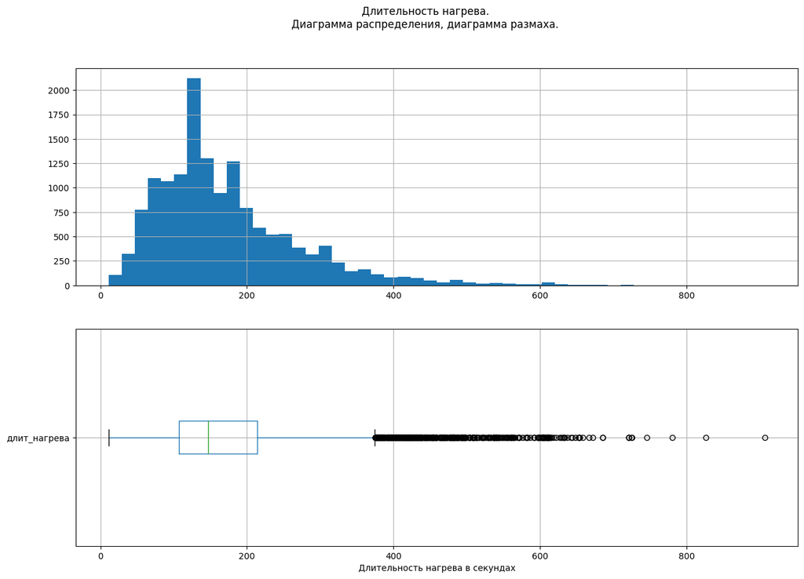

```
count    14876.000000
mean       171.670946
std         98.186803
min         11.000000
25%        107.000000
50%        147.000000
75%        214.000000
max        907.000000
Name: длит_нагрева, dtype: float64
```

```python
# исследуем длительности нагрева
plot_hist_boxplot(df=data_arc_new,
                  column='длит_нагрева',
                  title='Длительность нагрева.\n\
Диаграмма распределения, диаграмма размаха.',
                  xlabel='Длительность нагрева в секундах',
                  bins=[50])
```

**Итог:**

- На гистограмме длительности нагрева имеются пики, что выглядит неестественно.
- На диаграмме размаха есть выбросы, но их нельзя назвать аномалиями.
- Медианная продолжительность нагрева: 147 секунд, минимальное - 11 секунд, максимальное 907 секунд.

**Исследуем столбцы: `активная_мощность`, `реактивная_мощность`.**

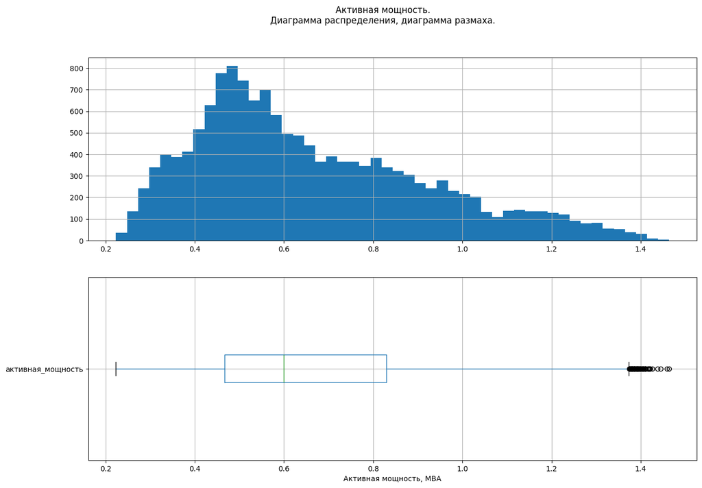

```
count    14876.000000
mean         0.662752
std          0.258885
min          0.223120
25%          0.467115
50%          0.599587
75%          0.830070
max          1.463773
Name: активная_мощность, dtype: float64
```

```python
# исследуем данные активной мощности
plot_hist_boxplot(df=data_arc_new,
                  column='активная_мощность',
                  title='Активная мощность.\n\
Диаграмма распределения, диаграмма размаха.',
                  xlabel='Активная мощность, МВА',
                  bins=[50])
```

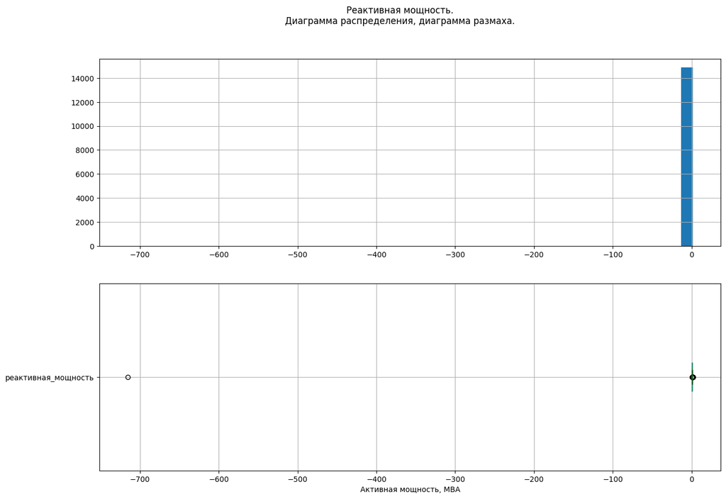

```
count    14876.000000
mean         0.438986
std          5.873485
min       -715.479924
25%          0.337175
50%          0.441639
75%          0.608201
max          1.270284
Name: реактивная_мощность, dtype: float64
```

```python
# исследуем данные реактивной мощности
plot_hist_boxplot(df=data_arc_new,
                  column='реактивная_мощность',
                  title='Реактивная мощность.\n\
Диаграмма распределения, диаграмма размаха.',
                  xlabel='Активная мощность, МВА',
                  bins=[50])
```

В значениях реактивной мощности есть отрицательные числа, что является аномалией. Необходима предобработка. Исследуем только неотрицательные значения реактивной мощности.

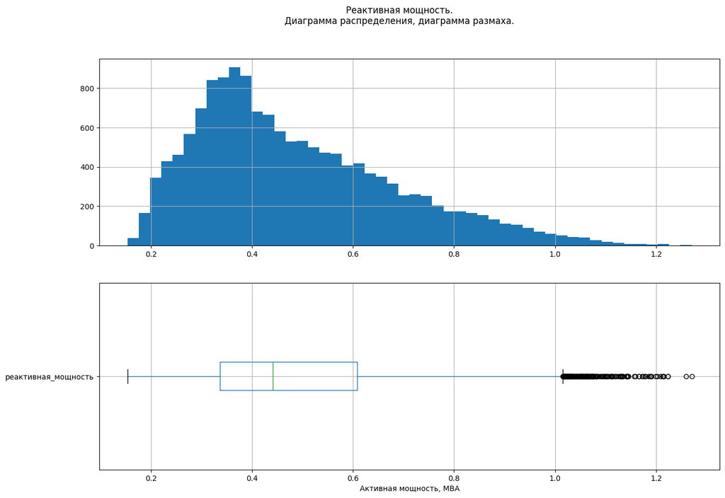

```
count    14875.000000
mean         0.487115
std          0.197612
min          0.153777
25%          0.337190
50%          0.441665
75%          0.608223
max          1.270284
Name: реактивная_мощность, dtype: float64
```

```python
# исследуем неотрицательные данные реактивной мощности
plot_hist_boxplot(df=data_arc_new[data_arc_new['реактивная_мощность'] >= 0],
                  column='реактивная_мощность',
                  title='Реактивная мощность.\n\
Диаграмма распределения, диаграмма размаха.',
                  xlabel='Активная мощность, МВА',
                  bins=[50])
```

**Итог:**

- Распределение наблюдений на гистограммах активной и реактивной мощностей не выглядят нормальными.
- В значениях реактивной мощности есть как минимум одно аномальное отрицательное значение. Отрицительных значений быть не должно (по информации от заказчика), поэтому на этапе предобработки необходимо такие строки удалить.
- На диаграммах размаха есть выбросы вверх, они выглядят естественно и не требуют предобработки.

### Объём подачи сыпучих материалов (data_bulk_new)

**Изучим датафрейм с объемами сыпучих материалов `data_bulk_new`.**

```python
# выведем первые строки data_bulk_new
data_bulk_new.head()
```

| партия | сыпуч_мат_1 | сыпуч_мат_2 | сыпуч_мат_3 | сыпуч_мат_4 | сыпуч_мат_5 | сыпуч_мат_6 | сыпуч_мат_7 | сыпуч_мат_8 | сыпуч_мат_9 | сыпуч_мат_10 | сыпуч_мат_11 | сыпуч_мат_12 | сыпуч_мат_13 | сыпуч_мат_14 | сыпуч_мат_15 |
| --- | --- | --- | --- | --- | --- | --- | --- | --- | --- | --- | --- | --- | --- | --- | --- |
| 1 | NaN | NaN | NaN | 43.0 | NaN | NaN | NaN | NaN | NaN | NaN | NaN | 206.0 | NaN | 150.0 | 154.0 |
| 2 | NaN | NaN | NaN | 73.0 | NaN | NaN | NaN | NaN | NaN | NaN | NaN | 206.0 | NaN | 149.0 | 154.0 |
| 3 | NaN | NaN | NaN | 34.0 | NaN | NaN | NaN | NaN | NaN | NaN | NaN | 205.0 | NaN | 152.0 | 153.0 |
| 4 | NaN | NaN | NaN | 81.0 | NaN | NaN | NaN | NaN | NaN | NaN | NaN | 207.0 | NaN | 153.0 | 154.0 |
| 5 | NaN | NaN | NaN | 78.0 | NaN | NaN | NaN | NaN | NaN | NaN | NaN | 203.0 | NaN | 151.0 | 152.0 |

Построим гистограммы и выведем основные описательные статистики объема подачи для всех сыпучих материалов.

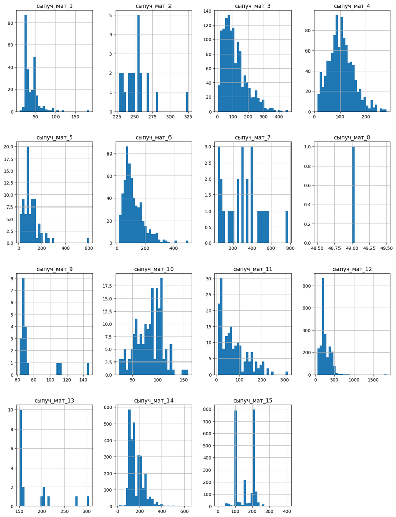

```python
# построим гистограммы
data_bulk_new.hist(figsize=(15, 20), bins=30)
plt.show()
```

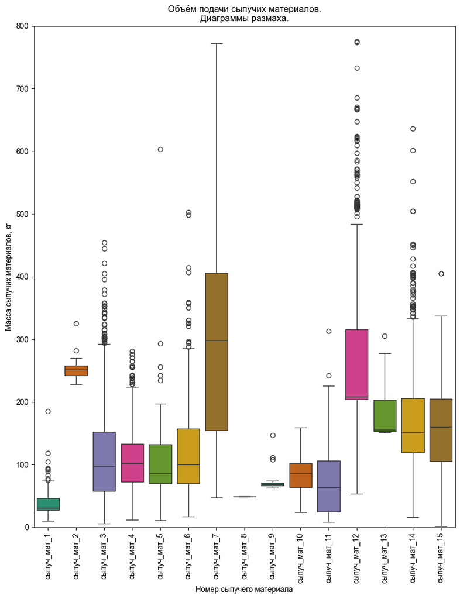

```python
# построим диаграммы размаха
ax = plt.subplots(figsize = (10,12))
ax = sns.boxplot(x="variable", y="value",
                 data=pd.melt(data_bulk_new), palette=palette)
ax.set_title('Объём подачи сыпучих материалов.\nДиаграммы размаха.')
ax.set_ylabel('Масса сыпучих материалов, кг')
ax.set_xlabel('Номер сыпучего материала')
ax.set_xticklabels(ax.get_xticklabels(),rotation=90)
sns.set_style('darkgrid')

plt.ylim(0, 800)
plt.show()
```

```python
# выведем основные описательные статистики
data_bulk_new.describe()
```

|  | сыпуч_мат_1 | сыпуч_мат_2 | сыпуч_мат_3 | сыпуч_мат_4 | сыпуч_мат_5 | сыпуч_мат_6 | сыпуч_мат_7 | сыпуч_мат_8 | сыпуч_мат_9 | сыпуч_мат_10 | сыпуч_мат_11 | сыпуч_мат_12 | сыпуч_мат_13 | сыпуч_мат_14 | сыпуч_мат_15 |
| --- | --- | --- | --- | --- | --- | --- | --- | --- | --- | --- | --- | --- | --- | --- | --- |
| count | 252.000000 | 22.000000 | 1298.000000 | 1014.000000 | 77.000000 | 576.000000 | 25.000000 | 1.0 | 19.000000 | 176.000000 | 177.000000 | 2450.000000 | 18.000000 | 2806.000000 | 2248.000000 |
| mean | 39.242063 | 253.045455 | 113.879045 | 104.394477 | 107.025974 | 118.925347 | 305.600000 | 49.0 | 76.315789 | 83.284091 | 76.819209 | 260.471020 | 181.111111 | 170.284747 | 160.513345 |
| std | 18.277654 | 21.180578 | 75.483494 | 48.184126 | 81.790646 | 72.057776 | 191.022904 | NaN | 21.720581 | 26.060347 | 59.655365 | 120.649269 | 46.088009 | 65.868652 | 51.765319 |
| min | 10.000000 | 228.000000 | 6.000000 | 12.000000 | 11.000000 | 17.000000 | 47.000000 | 49.0 | 63.000000 | 24.000000 | 8.000000 | 53.000000 | 151.000000 | 16.000000 | 1.000000 |
| 25% | 27.000000 | 242.000000 | 58.000000 | 72.000000 | 70.000000 | 69.750000 | 155.000000 | 49.0 | 66.000000 | 64.000000 | 25.000000 | 204.000000 | 153.250000 | 119.000000 | 105.000000 |
| 50% | 31.000000 | 251.500000 | 97.500000 | 102.000000 | 86.000000 | 100.000000 | 298.000000 | 49.0 | 68.000000 | 86.500000 | 64.000000 | 208.000000 | 155.500000 | 151.000000 | 160.000000 |
| 75% | 46.000000 | 257.750000 | 152.000000 | 133.000000 | 132.000000 | 157.000000 | 406.000000 | 49.0 | 70.500000 | 102.000000 | 106.000000 | 316.000000 | 203.500000 | 205.750000 | 205.000000 |
| max | 185.000000 | 325.000000 | 454.000000 | 281.000000 | 603.000000 | 503.000000 | 772.000000 | 49.0 | 147.000000 | 159.000000 | 313.000000 | 1849.000000 | 305.000000 | 636.000000 | 405.000000 |

**Итог:**

- Гистограммы подачи сыпучих материалов выглядят неоднородно, что естественно, поскольку некоторые материалы подавались редко (всего 1 раз подавался сыпучий материал №8, 19 раз сыпучий материал №9)
- В сыпучем материале №12 обнаружены существенные выбросы, максимальное значение: 1849 кг. при медиане 208 кг.
- Многочисленные пропуски в объёмах сыпучих материалов означают, что материал не добавлялся. Заменим эти значения нулями во время последующей предобработки.

### Время подачи сыпучих материалов (data_bulk_time_new)

```python
# выведем первые строки data_bulk_new
data_bulk_time_new.head()
```

| партия | сыпуч_мат_1 | сыпуч_мат_2 | сыпуч_мат_3 | сыпуч_мат_4 | сыпуч_мат_5 | сыпуч_мат_6 | сыпуч_мат_7 | сыпуч_мат_8 | сыпуч_мат_9 | сыпуч_мат_10 | сыпуч_мат_11 | сыпуч_мат_12 | сыпуч_мат_13 | сыпуч_мат_14 | сыпуч_мат_15 |
| --- | --- | --- | --- | --- | --- | --- | --- | --- | --- | --- | --- | --- | --- | --- | --- |
| 1 | NaT | NaT | NaT | 2019-05-03 11:28:48 | NaT | NaT | NaT | NaT | NaT | NaT | NaT | 2019-05-03 11:24:31 | NaT | 2019-05-03 11:14:50 | 2019-05-03 11:10:43 |
| 2 | NaT | NaT | NaT | 2019-05-03 11:36:50 | NaT | NaT | NaT | NaT | NaT | NaT | NaT | 2019-05-03 11:53:30 | NaT | 2019-05-03 11:48:37 | 2019-05-03 11:44:39 |
| 3 | NaT | NaT | NaT | 2019-05-03 12:32:39 | NaT | NaT | NaT | NaT | NaT | NaT | NaT | 2019-05-03 12:27:13 | NaT | 2019-05-03 12:21:01 | 2019-05-03 12:16:16 |
| 4 | NaT | NaT | NaT | 2019-05-03 12:43:22 | NaT | NaT | NaT | NaT | NaT | NaT | NaT | 2019-05-03 12:58:00 | NaT | 2019-05-03 12:51:11 | 2019-05-03 12:46:36 |
| 5 | NaT | NaT | NaT | 2019-05-03 13:30:47 | NaT | NaT | NaT | NaT | NaT | NaT | NaT | 2019-05-03 13:30:47 | NaT | 2019-05-03 13:34:12 | 2019-05-03 13:30:47 |

```python
# выведем общую информацию о датафрейме
data_bulk_time_new.info()
```

[output not shown]

Выведем за какой период времени данные.

```python
a = pd.DatetimeIndex(data_bulk_time_new['сыпуч_мат_1']).year.min()
b = pd.DatetimeIndex(data_bulk_time_new['сыпуч_мат_1']).year.max()
print(f'Измерения производились с {int(a)} по {int(b)} г.г.')
```

```
Измерения производились с 2019 по 2019 г.г.
```

**Время подачи должно совпадать со сременем нагрева (как минимум тот же день или время нагрева происходит на день раньше), проверим это. Поскольку время нагрева длится несколько минут, достаточно сравнить время подачи супучих материалов с началом нагрева дугой.**

```python
# выведем первые строки датафрейма data_arc_new
data_arc_new.head()
```

|  | партия | начало_нагрева_дугой | конец_нагрева_дугой | активная_мощность | реактивная_мощность | длит_нагрева |
| --- | --- | --- | --- | --- | --- | --- |
| 0 | 1 | 2019-05-03 11:02:14 | 2019-05-03 11:06:02 | 0.305130 | 0.211253 | 228 |
| 1 | 1 | 2019-05-03 11:07:28 | 2019-05-03 11:10:33 | 0.765658 | 0.477438 | 185 |
| 2 | 1 | 2019-05-03 11:11:44 | 2019-05-03 11:14:36 | 0.580313 | 0.430460 | 172 |
| 3 | 1 | 2019-05-03 11:18:14 | 2019-05-03 11:24:19 | 0.518496 | 0.379979 | 365 |
| 4 | 1 | 2019-05-03 11:26:09 | 2019-05-03 11:28:37 | 0.867133 | 0.643691 | 148 |

```python
# группируем данные по номеру партии, назовем датафрейм 'data_arc_new_grouped'
# выбираем минимальную (начальную) дату для каждой партии
data_arc_new_grouped = \
data_arc_new.groupby('партия').min()['начало_нагрева_дугой']

# выведем первые строки
data_arc_new_grouped.head()
```

```
партия
1   2019-05-03 11:02:14
2   2019-05-03 11:34:14
3   2019-05-03 12:06:54
4   2019-05-03 12:39:37
5   2019-05-03 13:11:13
Name: начало_нагрева_дугой, dtype: datetime64[ns]
```

```python
# нас интересует только день, поэтому избавимся от значений времени
data_arc_new_grouped = data_arc_new_grouped.dt.normalize()

# выведем первые строки
data_arc_new_grouped.head()
```

```
партия
1   2019-05-03
2   2019-05-03
3   2019-05-03
4   2019-05-03
5   2019-05-03
Name: начало_нагрева_дугой, dtype: datetime64[ns]
```

```python
# с помощью функции создадим столбец, в который запишем день
# засыпки (выберем минимальный день из данных по всем сыпучим материалам)
def day_check(row):

    # Задаем min_ с конкретным временным разрешением, совместимым с pandas Timestamp
    min_ = np.datetime64('2050-09-24T00:00:00', 'ns')
    for i in data_bulk_time_new.columns:
        if pd.isnull(row[i]):
            continue

        # Приводим все данные к одному временному разрешению перед сравнением
        current_time = np.datetime64(row[i], 'ns')
        if current_time < min_:
            min_ = current_time

    return min_

# создадим столбец 'день_засыпки' и вычисленное значение функцией day_check
data_bulk_time_new['день_засыпки'] = data_bulk_time_new.apply(day_check, axis=1)
data_bulk_time_new.head()
```

| партия | сыпуч_мат_1 | сыпуч_мат_2 | сыпуч_мат_3 | сыпуч_мат_4 | сыпуч_мат_5 | сыпуч_мат_6 | сыпуч_мат_7 | сыпуч_мат_8 | сыпуч_мат_9 | сыпуч_мат_10 | сыпуч_мат_11 | сыпуч_мат_12 | сыпуч_мат_13 | сыпуч_мат_14 | сыпуч_мат_15 | день_засыпки |
| --- | --- | --- | --- | --- | --- | --- | --- | --- | --- | --- | --- | --- | --- | --- | --- | --- |
| 1 | NaT | NaT | NaT | 2019-05-03 11:28:48 | NaT | NaT | NaT | NaT | NaT | NaT | NaT | 2019-05-03 11:24:31 | NaT | 2019-05-03 11:14:50 | 2019-05-03 11:10:43 | 2019-05-03 11:10:43 |
| 2 | NaT | NaT | NaT | 2019-05-03 11:36:50 | NaT | NaT | NaT | NaT | NaT | NaT | NaT | 2019-05-03 11:53:30 | NaT | 2019-05-03 11:48:37 | 2019-05-03 11:44:39 | 2019-05-03 11:36:50 |
| 3 | NaT | NaT | NaT | 2019-05-03 12:32:39 | NaT | NaT | NaT | NaT | NaT | NaT | NaT | 2019-05-03 12:27:13 | NaT | 2019-05-03 12:21:01 | 2019-05-03 12:16:16 | 2019-05-03 12:16:16 |
| 4 | NaT | NaT | NaT | 2019-05-03 12:43:22 | NaT | NaT | NaT | NaT | NaT | NaT | NaT | 2019-05-03 12:58:00 | NaT | 2019-05-03 12:51:11 | 2019-05-03 12:46:36 | 2019-05-03 12:43:22 |
| 5 | NaT | NaT | NaT | 2019-05-03 13:30:47 | NaT | NaT | NaT | NaT | NaT | NaT | NaT | 2019-05-03 13:30:47 | NaT | 2019-05-03 13:34:12 | 2019-05-03 13:30:47 | 2019-05-03 13:30:47 |

```python
# перезапишем столбец 'день_засыпки', оставив только дату без времени
data_bulk_time_new['день_засыпки'] = \
data_bulk_time_new['день_засыпки'].dt.normalize()
```

```python
# добавим в датафрейм data_bulk_time_new дни начала нагрева из data_arc_new_grouped
# объединение проводим по номеру партии
data_bulk_time_new = data_bulk_time_new.join(data_arc_new_grouped,
                                             how='left')
data_bulk_time_new.head()
```

| партия | сыпуч_мат_1 | сыпуч_мат_2 | сыпуч_мат_3 | сыпуч_мат_4 | сыпуч_мат_5 | сыпуч_мат_6 | сыпуч_мат_7 | сыпуч_мат_8 | сыпуч_мат_9 | сыпуч_мат_10 | сыпуч_мат_11 | сыпуч_мат_12 | сыпуч_мат_13 | сыпуч_мат_14 | сыпуч_мат_15 | день_засыпки | начало_нагрева_дугой |
| --- | --- | --- | --- | --- | --- | --- | --- | --- | --- | --- | --- | --- | --- | --- | --- | --- | --- |
| 1 | NaT | NaT | NaT | 2019-05-03 11:28:48 | NaT | NaT | NaT | NaT | NaT | NaT | NaT | 2019-05-03 11:24:31 | NaT | 2019-05-03 11:14:50 | 2019-05-03 11:10:43 | 2019-05-03 | 2019-05-03 |
| 2 | NaT | NaT | NaT | 2019-05-03 11:36:50 | NaT | NaT | NaT | NaT | NaT | NaT | NaT | 2019-05-03 11:53:30 | NaT | 2019-05-03 11:48:37 | 2019-05-03 11:44:39 | 2019-05-03 | 2019-05-03 |
| 3 | NaT | NaT | NaT | 2019-05-03 12:32:39 | NaT | NaT | NaT | NaT | NaT | NaT | NaT | 2019-05-03 12:27:13 | NaT | 2019-05-03 12:21:01 | 2019-05-03 12:16:16 | 2019-05-03 | 2019-05-03 |
| 4 | NaT | NaT | NaT | 2019-05-03 12:43:22 | NaT | NaT | NaT | NaT | NaT | NaT | NaT | 2019-05-03 12:58:00 | NaT | 2019-05-03 12:51:11 | 2019-05-03 12:46:36 | 2019-05-03 | 2019-05-03 |
| 5 | NaT | NaT | NaT | 2019-05-03 13:30:47 | NaT | NaT | NaT | NaT | NaT | NaT | NaT | 2019-05-03 13:30:47 | NaT | 2019-05-03 13:34:12 | 2019-05-03 13:30:47 | 2019-05-03 | 2019-05-03 |

```python
# создадим функцию, которая сравнит день засыпки и день начала нагрева
# также учтём, что начало нагрева может быть на день раньше
def day_match(row):
    a = row['день_засыпки']
    b = row['начало_нагрева_дугой']
    return (a == b or \
            a == b + pd.Timedelta(days=+1))

# добавим в датафрейм data_bulk_time_new столбец 'даты_совпадают'
# данные в этом столбце имеют булев тип
data_bulk_time_new['даты_совпадают'] = data_bulk_time_new.apply(day_match, axis=1)
data_bulk_time_new.head()
```

| партия | сыпуч_мат_1 | сыпуч_мат_2 | сыпуч_мат_3 | сыпуч_мат_4 | сыпуч_мат_5 | сыпуч_мат_6 | сыпуч_мат_7 | сыпуч_мат_8 | сыпуч_мат_9 | сыпуч_мат_10 | сыпуч_мат_11 | сыпуч_мат_12 | сыпуч_мат_13 | сыпуч_мат_14 | сыпуч_мат_15 | день_засыпки | начало_нагрева_дугой | даты_совпадают |
| --- | --- | --- | --- | --- | --- | --- | --- | --- | --- | --- | --- | --- | --- | --- | --- | --- | --- | --- |
| 1 | NaT | NaT | NaT | 2019-05-03 11:28:48 | NaT | NaT | NaT | NaT | NaT | NaT | NaT | 2019-05-03 11:24:31 | NaT | 2019-05-03 11:14:50 | 2019-05-03 11:10:43 | 2019-05-03 | 2019-05-03 | True |
| 2 | NaT | NaT | NaT | 2019-05-03 11:36:50 | NaT | NaT | NaT | NaT | NaT | NaT | NaT | 2019-05-03 11:53:30 | NaT | 2019-05-03 11:48:37 | 2019-05-03 11:44:39 | 2019-05-03 | 2019-05-03 | True |
| 3 | NaT | NaT | NaT | 2019-05-03 12:32:39 | NaT | NaT | NaT | NaT | NaT | NaT | NaT | 2019-05-03 12:27:13 | NaT | 2019-05-03 12:21:01 | 2019-05-03 12:16:16 | 2019-05-03 | 2019-05-03 | True |
| 4 | NaT | NaT | NaT | 2019-05-03 12:43:22 | NaT | NaT | NaT | NaT | NaT | NaT | NaT | 2019-05-03 12:58:00 | NaT | 2019-05-03 12:51:11 | 2019-05-03 12:46:36 | 2019-05-03 | 2019-05-03 | True |
| 5 | NaT | NaT | NaT | 2019-05-03 13:30:47 | NaT | NaT | NaT | NaT | NaT | NaT | NaT | 2019-05-03 13:30:47 | NaT | 2019-05-03 13:34:12 | 2019-05-03 13:30:47 | 2019-05-03 | 2019-05-03 | True |

```python
# вычислим сколько дат не совпадают
len(data_bulk_time_new) - data_bulk_time_new['даты_совпадают'].sum()
```

```
1
```

```python
# выведем строку с несовпадающей датой
data_bulk_time_new[data_bulk_time_new['даты_совпадают'] == False]
```

| партия | сыпуч_мат_1 | сыпуч_мат_2 | сыпуч_мат_3 | сыпуч_мат_4 | сыпуч_мат_5 | сыпуч_мат_6 | сыпуч_мат_7 | сыпуч_мат_8 | сыпуч_мат_9 | сыпуч_мат_10 | сыпуч_мат_11 | сыпуч_мат_12 | сыпуч_мат_13 | сыпуч_мат_14 | сыпуч_мат_15 | день_засыпки | начало_нагрева_дугой | даты_совпадают |
| --- | --- | --- | --- | --- | --- | --- | --- | --- | --- | --- | --- | --- | --- | --- | --- | --- | --- | --- |
| 279 | NaT | NaT | NaT | NaT | NaT | 2019-05-14 10:13:37 | NaT | NaT | NaT | NaT | NaT | NaT | NaT | NaT | NaT | 2019-05-14 | NaT | False |

```python
# найдем аномальную партия в data_arc_new
data_arc_new[data_arc_new['партия'] == 279]
```

|  | партия | начало_нагрева_дугой | конец_нагрева_дугой | активная_мощность | реактивная_мощность | длит_нагрева |
| --- | --- | --- | --- | --- | --- | --- |

Как видим, в данной строке начало нагрева имеет пропуск. Данные о нагреве отсутствуют. Во время финального объединения данных исключим подобные строки.

- В датах имеется множество пропусков, поскольку некоторые материалы не добавлялись.
- Время подачи материалов выглядит корректно.
- Информацию о времени подачи материалов для обучения моделей использовать нет необходимости, поэтому при объединении не будем добавлять эти данные в итоговую табдлицу.

### Продувка сплава газом (data_gas_new)

```python
# выведем первые строки датафрейма
data_gas_new.head()
```

| партия | газ_1 |
| --- | --- |
| 1 | 29.749986 |
| 2 | 12.555561 |
| 3 | 28.554793 |
| 4 | 18.841219 |
| 5 | 5.413692 |

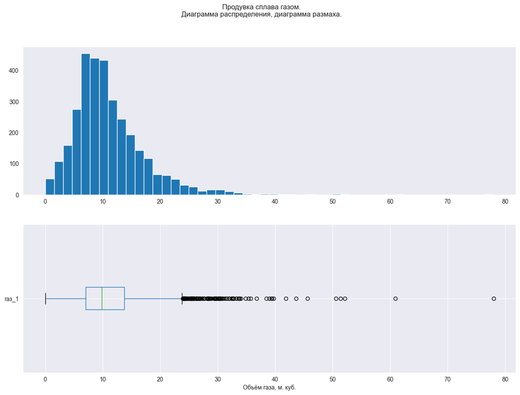

```
count    3239.000000
mean       11.002062
std         6.220327
min         0.008399
25%         7.043089
50%         9.836267
75%        13.769915
max        77.995040
Name: газ_1, dtype: float64
```

```python
# исследуем объём подаваемого газа для продувки сплава
plot_hist_boxplot(df=data_gas_new,
                  column='газ_1',
                  title='Продувка сплава газом.\n\
Диаграмма распределения, диаграмма размаха.',
                  xlabel='Объём газа, м. куб.',
                  bins=[50])
```

**Итог:**

- Распределение объёмов газа не выглядит нормальным.
- Имеются выбросы вверх до ~78 м. куб., что выглядит естественно, но для улучшения прогнозной модели наиболее мощные выбросы можно удалить из обучающей выборки.

### Температура сплава (data_temp_new)

```python
# выведем первые строки датафрейма
data_temp_new.head()
```

|  | партия | время_замера | температура |
| --- | --- | --- | --- |
| 0 | 1 | 2019-05-03 11:02:04 | 1571.0 |
| 1 | 1 | 2019-05-03 11:07:18 | 1604.0 |
| 2 | 1 | 2019-05-03 11:11:34 | 1618.0 |
| 3 | 1 | 2019-05-03 11:18:04 | 1601.0 |
| 4 | 1 | 2019-05-03 11:25:59 | 1606.0 |

```python
# выведем общую информацию о датафрейме
data_temp_new.info()
```

```
<class 'pandas.core.frame.DataFrame'>
RangeIndex: 18092 entries, 0 to 18091
Data columns (total 3 columns):
 #   Column        Non-Null Count  Dtype
---  ------        --------------  -----
 0   партия        18092 non-null  int64
 1   время_замера  18092 non-null  datetime64[ns]
 2   температура   14665 non-null  float64
dtypes: datetime64[ns](1), float64(1), int64(1)
memory usage: 424.2 KB
```

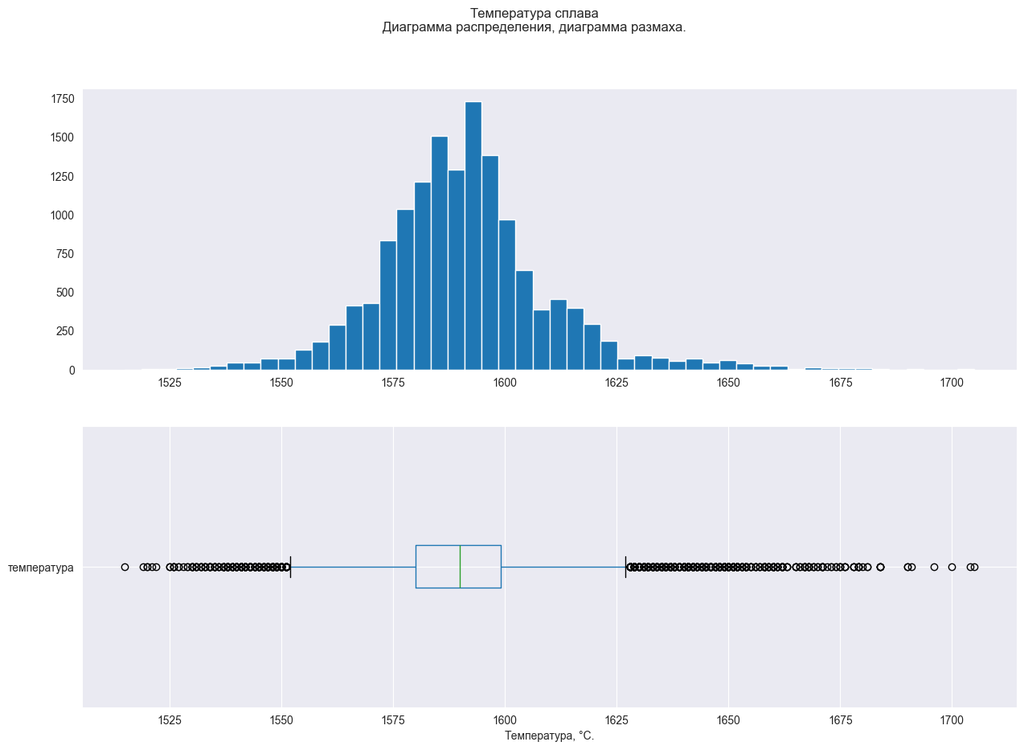

```
count    14660.000000
mean      1590.852729
std         19.143141
min       1515.000000
25%       1580.000000
50%       1590.000000
75%       1599.000000
max       1705.000000
Name: температура, dtype: float64
```

```python
# исследуем температуру нагрева
plot_hist_boxplot(df=data_temp_new[data_temp_new['температура'] >= 1500],
                  column='температура',
                  title='Температура сплава\n\
Диаграмма распределения, диаграмма размаха.',
                  xlabel='Температура, °C.',
                  bins=[50])
```

Сравним даты измерения температуры и времени нагрева. Необходимо убедиться, что они совпадают. Для этого сравним м\время начала нагрева с минимальной датой по каждой партии.

```python
# группируем время нагрева по номеру партии, назовем датафрейм 'data_temp_new_grouped'
# выбираем минимальную (начальную) дату для каждой партии
data_temp_new_grouped = \
data_temp_new.groupby('партия').min()['время_замера']

# оставим только дни
data_temp_new_grouped = data_temp_new_grouped.dt.normalize()

# выведем первые строки
data_temp_new_grouped.head()
```

```
партия
1   2019-05-03
2   2019-05-03
3   2019-05-03
4   2019-05-03
5   2019-05-03
Name: время_замера, dtype: datetime64[ns]
```

```python
# добавим в датафрейм data_temp_new_grouped дни начала нагрева из data_arc_new_grouped
# объединение проводим по номеру партии
data_temp_new_grouped = pd.concat([data_temp_new_grouped, data_arc_new_grouped], axis=1).reset_index()
data_temp_new_grouped.head()
```

|  | партия | время_замера | начало_нагрева_дугой |
| --- | --- | --- | --- |
| 0 | 1 | 2019-05-03 | 2019-05-03 |
| 1 | 2 | 2019-05-03 | 2019-05-03 |
| 2 | 3 | 2019-05-03 | 2019-05-03 |
| 3 | 4 | 2019-05-03 | 2019-05-03 |
| 4 | 5 | 2019-05-03 | 2019-05-03 |

```python
data_temp_new_grouped.info()
```

```
<class 'pandas.core.frame.DataFrame'>
RangeIndex: 3216 entries, 0 to 3215
Data columns (total 3 columns):
 #   Column                Non-Null Count  Dtype
---  ------                --------------  -----
 0   партия                3216 non-null   int64
 1   время_замера          3216 non-null   datetime64[ns]
 2   начало_нагрева_дугой  3214 non-null   datetime64[ns]
dtypes: datetime64[ns](2), int64(1)
memory usage: 75.5 KB
```

```python
# создадим функцию, которая сравнит день засыпки и день начала нагрева
# также учтём, что начало нагрева может быть на день раньше
def day_match(row):
    a = row['время_замера']
    b = row['начало_нагрева_дугой']
    return (a == b or \
            a == b + pd.Timedelta(days=+1))

# добавим в датафрейм data_bulk_time_new столбец 'даты_совпадают'
# данные в этом столбце имеют булев тип
data_temp_new_grouped['даты_совпадают'] = data_temp_new_grouped.apply(day_match, axis=1)
data_temp_new_grouped.head()
```

|  | партия | время_замера | начало_нагрева_дугой | даты_совпадают |
| --- | --- | --- | --- | --- |
| 0 | 1 | 2019-05-03 | 2019-05-03 | True |
| 1 | 2 | 2019-05-03 | 2019-05-03 | True |
| 2 | 3 | 2019-05-03 | 2019-05-03 | True |
| 3 | 4 | 2019-05-03 | 2019-05-03 | True |
| 4 | 5 | 2019-05-03 | 2019-05-03 | True |

```python
# вычислим сколько дат не совпадают
len(data_temp_new_grouped) - data_temp_new_grouped['даты_совпадают'].sum()
```

```
2
```

```python
# выведем строки с несовпадающей датой
data_temp_new_grouped[data_temp_new_grouped['даты_совпадают'] == False]
```

|  | партия | время_замера | начало_нагрева_дугой | даты_совпадают |
| --- | --- | --- | --- | --- |
| 192 | 195 | 2019-05-11 | NaT | False |
| 276 | 279 | 2019-05-14 | NaT | False |

```python
# найдем аномальные строки в data_arc_new
data_arc_new.query('партия in (195, 279)')
```

|  | партия | начало_нагрева_дугой | конец_нагрева_дугой | активная_мощность | реактивная_мощность | длит_нагрева |
| --- | --- | --- | --- | --- | --- | --- |

В данных строках начало нагрева имеет пропуск. Данные о нагреве отсутствуют. Во время финального объединения данных исключим подобные строки.

**Итог:**

- На гистограмме температуры сплава видны пики.
- На диаграмме размаха заметны многочисленные выбросы.
- По информации от заказчика температура ниже 1500 °C являются аномальныой, такие данные необходимо удалить.
- Время измерения температуры сплава выглядит корректно.

### Объём подачи проволоки (data_wire_new)

```python
# выведем первые строки датафрейма
data_wire_new.head()
```

| партия | проволока_1 | проволока_2 | проволока_3 | проволока_4 | проволока_5 | проволока_6 | проволока_7 | проволока_8 | проволока_9 |
| --- | --- | --- | --- | --- | --- | --- | --- | --- | --- |
| 1 | 60.059998 | NaN | NaN | NaN | NaN | NaN | NaN | NaN | NaN |
| 2 | 96.052315 | NaN | NaN | NaN | NaN | NaN | NaN | NaN | NaN |
| 3 | 91.160157 | NaN | NaN | NaN | NaN | NaN | NaN | NaN | NaN |
| 4 | 89.063515 | NaN | NaN | NaN | NaN | NaN | NaN | NaN | NaN |
| 5 | 89.238236 | 9.11456 | NaN | NaN | NaN | NaN | NaN | NaN | NaN |

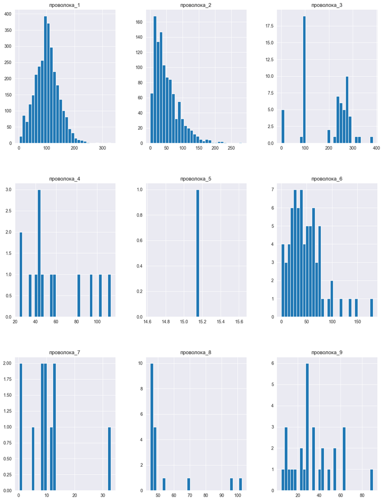

```python
# построим гистограммы
data_wire_new.hist(figsize=(15, 20), bins=30)
plt.show()
```

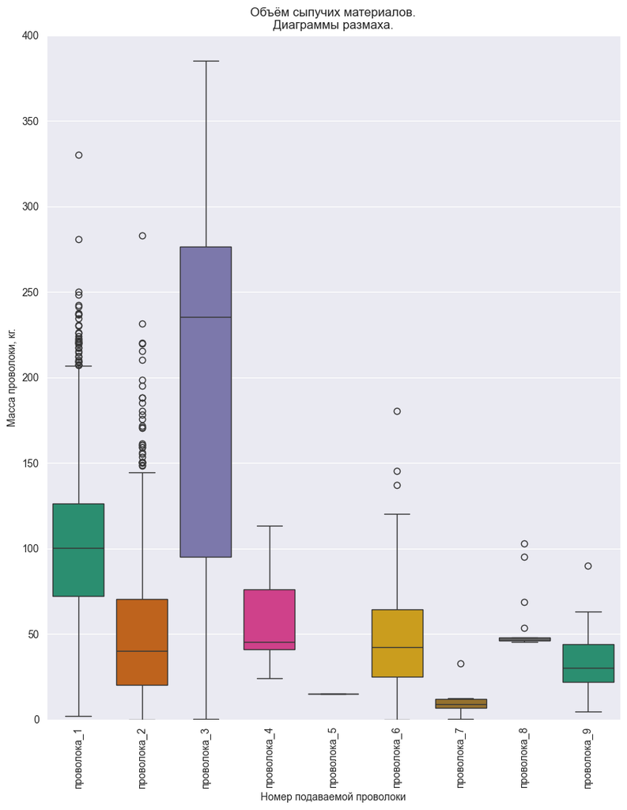

```python
# построим диаграммы размаха
ax = plt.subplots(figsize = (10,12))
ax = sns.boxplot(x="variable", y="value",
                 data=pd.melt(data_wire_new), palette=palette)
ax.set_title('Объём сыпучих материалов.\nДиаграммы размаха.')
ax.set_ylabel('Масса проволоки, кг.')
ax.set_xlabel('Номер подаваемой проволоки')
ax.set_xticklabels(ax.get_xticklabels(),rotation=90)
sns.set_style('darkgrid')

plt.ylim(0, 400)
plt.show()
```

```python
# выведем основные описательные статистики
data_wire_new.describe()
```

|  | проволока_1 | проволока_2 | проволока_3 | проволока_4 | проволока_5 | проволока_6 | проволока_7 | проволока_8 | проволока_9 |
| --- | --- | --- | --- | --- | --- | --- | --- | --- | --- |
| count | 3055.000000 | 1079.000000 | 63.000000 | 14.000000 | 1.000 | 73.000000 | 11.000000 | 19.000000 | 29.000000 |
| mean | 100.895853 | 50.577323 | 189.482681 | 57.442841 | 15.132 | 48.016974 | 10.039007 | 53.625193 | 34.155752 |
| std | 42.012518 | 39.320216 | 99.513444 | 28.824667 | NaN | 33.919845 | 8.610584 | 16.881728 | 19.931616 |
| min | 1.918800 | 0.030160 | 0.144144 | 24.148801 | 15.132 | 0.034320 | 0.234208 | 45.076721 | 4.622800 |
| 25% | 72.115684 | 20.193680 | 95.135044 | 40.807002 | 15.132 | 25.053600 | 6.762756 | 46.094879 | 22.058401 |
| 50% | 100.158234 | 40.142956 | 235.194977 | 45.234282 | 15.132 | 42.076324 | 9.017009 | 46.279999 | 30.066399 |
| 75% | 126.060483 | 70.227558 | 276.252014 | 76.124619 | 15.132 | 64.212723 | 11.886057 | 48.089603 | 43.862003 |
| max | 330.314424 | 282.780152 | 385.008668 | 113.231044 | 15.132 | 180.454575 | 32.847674 | 102.762401 | 90.053604 |

**Итог:**

- Гистограммы подачи проволоки не выглядят нормально, что естественно, поскольку некоторые материалы подавались редко (всего 1 раз подавалась проволока №5, 11 раз подавалась проволока №7)
- Существенные выбросы на диаграмме размаха также обусловлены малым числом наблюдений (например, проволока №8). Аномалий не обнаружено.
- Многочисленные пропуски в таблице означают, что проволока не добавлялась. Заменим эти значения нулями во время последующей предобработки.

### Время подачи проволоки (data_wire_time_new)

```python
# выведем первые строки data_bulk_new
data_wire_time_new.head()
```

| партия | проволока_1 | проволока_2 | проволока_3 | проволока_4 | проволока_5 | проволока_6 | проволока_7 | проволока_8 | проволока_9 |
| --- | --- | --- | --- | --- | --- | --- | --- | --- | --- |
| 1 | 2019-05-03 11:06:19 | NaT | NaT | NaT | NaT | NaT | NaT | NaT | NaT |
| 2 | 2019-05-03 11:36:50 | NaT | NaT | NaT | NaT | NaT | NaT | NaT | NaT |
| 3 | 2019-05-03 12:11:46 | NaT | NaT | NaT | NaT | NaT | NaT | NaT | NaT |
| 4 | 2019-05-03 12:43:22 | NaT | NaT | NaT | NaT | NaT | NaT | NaT | NaT |
| 5 | 2019-05-03 13:20:44 | 2019-05-03 13:15:34 | NaT | NaT | NaT | NaT | NaT | NaT | NaT |

```python
# выведем общую информацию о датафрейме
data_wire_time_new.info()
```

```
<class 'pandas.core.frame.DataFrame'>
Int64Index: 3081 entries, 1 to 3241
Data columns (total 9 columns):
 #   Column       Non-Null Count  Dtype
---  ------       --------------  -----
 0   проволока_1  3055 non-null   datetime64[ns]
 1   проволока_2  1079 non-null   datetime64[ns]
 2   проволока_3  63 non-null     datetime64[ns]
 3   проволока_4  14 non-null     datetime64[ns]
 4   проволока_5  1 non-null      datetime64[ns]
 5   проволока_6  73 non-null     datetime64[ns]
 6   проволока_7  11 non-null     datetime64[ns]
 7   проволока_8  19 non-null     datetime64[ns]
 8   проволока_9  29 non-null     datetime64[ns]
dtypes: datetime64[ns](9)
memory usage: 305.2 KB
```

**Время подачи проволоки должно совпадать со сременем нагрева (как минимум тот же день или время нагрева происходит на день раньше), проверим это. Поскольку время нагрева длится несколько минут, достаточно сравнить время подачи супучих материалов с началом нагрева дугой.**

```python
# с помощью функции создадим столбец, в который запишем день
# засыпки (выберем минимальный день из данных по всем сыпучим материалам)
def wire_day_check(row):

    # Задаем min_ с конкретным временным разрешением, совместимым с pandas Timestamp
    min_ = np.datetime64('2050-09-24', 'ns')
    for i in data_wire_time_new.columns:
        if pd.isnull(row[i]):
            continue

        # Приводим все данные к одному временному разрешению перед сравнением
        current_time = np.datetime64(row[i], 'ns')
        if current_time < min_:
            min_ = current_time

    return min_

# создадим столбец 'день_подачи' и вычисленное значение функцией day_check
data_wire_time_new['день_подачи'] = \
data_wire_time_new.apply(wire_day_check, axis=1)

data_wire_time_new.head()
```

| партия | проволока_1 | проволока_2 | проволока_3 | проволока_4 | проволока_5 | проволока_6 | проволока_7 | проволока_8 | проволока_9 | день_подачи |
| --- | --- | --- | --- | --- | --- | --- | --- | --- | --- | --- |
| 1 | 2019-05-03 11:06:19 | NaT | NaT | NaT | NaT | NaT | NaT | NaT | NaT | 2019-05-03 11:06:19 |
| 2 | 2019-05-03 11:36:50 | NaT | NaT | NaT | NaT | NaT | NaT | NaT | NaT | 2019-05-03 11:36:50 |
| 3 | 2019-05-03 12:11:46 | NaT | NaT | NaT | NaT | NaT | NaT | NaT | NaT | 2019-05-03 12:11:46 |
| 4 | 2019-05-03 12:43:22 | NaT | NaT | NaT | NaT | NaT | NaT | NaT | NaT | 2019-05-03 12:43:22 |
| 5 | 2019-05-03 13:20:44 | 2019-05-03 13:15:34 | NaT | NaT | NaT | NaT | NaT | NaT | NaT | 2019-05-03 13:15:34 |

```python
# перезапишем столбец 'день_подачи', оставив только дату без времени
data_wire_time_new['день_подачи'] = (data_wire_time_new['день_подачи']
                                     .dt.normalize())
```

```python
# добавим в датафрейм data_wire_time_new дни начала нагрева из data_arc_new_grouped
# объединение проводим по номеру партии
data_wire_time_new = data_wire_time_new.join(data_arc_new_grouped,
                                             how='left')
data_wire_time_new.head()
```

| партия | проволока_1 | проволока_2 | проволока_3 | проволока_4 | проволока_5 | проволока_6 | проволока_7 | проволока_8 | проволока_9 | день_подачи | начало_нагрева_дугой |
| --- | --- | --- | --- | --- | --- | --- | --- | --- | --- | --- | --- |
| 1 | 2019-05-03 11:06:19 | NaT | NaT | NaT | NaT | NaT | NaT | NaT | NaT | 2019-05-03 | 2019-05-03 |
| 2 | 2019-05-03 11:36:50 | NaT | NaT | NaT | NaT | NaT | NaT | NaT | NaT | 2019-05-03 | 2019-05-03 |
| 3 | 2019-05-03 12:11:46 | NaT | NaT | NaT | NaT | NaT | NaT | NaT | NaT | 2019-05-03 | 2019-05-03 |
| 4 | 2019-05-03 12:43:22 | NaT | NaT | NaT | NaT | NaT | NaT | NaT | NaT | 2019-05-03 | 2019-05-03 |
| 5 | 2019-05-03 13:20:44 | 2019-05-03 13:15:34 | NaT | NaT | NaT | NaT | NaT | NaT | NaT | 2019-05-03 | 2019-05-03 |

```python
# создадим функцию, которая сравнит день подачи проволоки и день начала нагрева
# также учтём, что начало нагрева может быть на день раньше
def day_match(row):
    a = row['день_подачи']
    b = row['начало_нагрева_дугой']
    return (a == b or \
            a == b + pd.Timedelta(days=+1))

# добавим в датафрейм data_wire_time_new столбец 'даты_совпадают'
# данные в этом столбце имеют булев тип
data_wire_time_new['даты_совпадают'] = data_wire_time_new.apply(day_match, axis=1)
data_wire_time_new.head()
```

| партия | проволока_1 | проволока_2 | проволока_3 | проволока_4 | проволока_5 | проволока_6 | проволока_7 | проволока_8 | проволока_9 | день_подачи | начало_нагрева_дугой | даты_совпадают |
| --- | --- | --- | --- | --- | --- | --- | --- | --- | --- | --- | --- | --- |
| 1 | 2019-05-03 11:06:19 | NaT | NaT | NaT | NaT | NaT | NaT | NaT | NaT | 2019-05-03 | 2019-05-03 | True |
| 2 | 2019-05-03 11:36:50 | NaT | NaT | NaT | NaT | NaT | NaT | NaT | NaT | 2019-05-03 | 2019-05-03 | True |
| 3 | 2019-05-03 12:11:46 | NaT | NaT | NaT | NaT | NaT | NaT | NaT | NaT | 2019-05-03 | 2019-05-03 | True |
| 4 | 2019-05-03 12:43:22 | NaT | NaT | NaT | NaT | NaT | NaT | NaT | NaT | 2019-05-03 | 2019-05-03 | True |
| 5 | 2019-05-03 13:20:44 | 2019-05-03 13:15:34 | NaT | NaT | NaT | NaT | NaT | NaT | NaT | 2019-05-03 | 2019-05-03 | True |

```python
# вычислим сколько дат не совпадают
len(data_wire_time_new) - data_wire_time_new['даты_совпадают'].sum()
```

```
1
```

```python
# выведем строку с несовпадающей датой
data_wire_time_new[data_wire_time_new['даты_совпадают'] == False]
```

| партия | проволока_1 | проволока_2 | проволока_3 | проволока_4 | проволока_5 | проволока_6 | проволока_7 | проволока_8 | проволока_9 | день_подачи | начало_нагрева_дугой | даты_совпадают |
| --- | --- | --- | --- | --- | --- | --- | --- | --- | --- | --- | --- | --- |
| 279 | 2019-05-14 10:13:37 | NaT | NaT | NaT | NaT | NaT | NaT | NaT | NaT | 2019-05-14 | NaT | False |

В данной строке начало нагрева имеет пропуск. Данные о нагреве отсутствуют. Во время финального объединения данных исключим подобные строки.

**Итог:**

- В датах имеется множество пропусков, поскольку некоторые виды проволоки не добавлялись.
- Время подачи материалов выглядит корректно.
- Информацию о времени подачи проволоки для обучения моделей использовать нет необходимости, поэтому при объединении не будем добавлять эти данные в итоговую табдлицу.

### Вывод раздела

**Электроды (`data_arc_new`)**

- В значениях реактивной мощности есть как минимум одно аномальное отрицательное значение. Отрицительных значений быть не должно (по информации от заказчика), поэтому на этапе предобработки необходимо такие строки удалить.
- В некоторых партиях отсутствуют данные о начале нагрева (например, партия 279).

**Объём подачи сыпучих материалов (`data_bulk_new`)**

- В сыпучем материале №12 обнаружены существенные выбросы, максимальное значение: 1849 кг при медиане 208 кг.
- Многочисленные пропуски в объёмах сыпучих материалов означают, что материал не добавлялся. Заменим эти значения нулями во время последующей предобработки.

**Время подачи сыпучих материалов (`data_bulk_time_new`)**:

- Информацию о времени подачи материалов для обучения моделей использовать нет необходимости, поэтому при объединении не будем добавлять эти данные в итоговую табдлицу.

**Продувка сплава газом (`data_gas_new`):**

- Обнаружены существенные выбросы.

**Температура сплава (`data_temp_new`):**

- По информации от заказчика температура ниже 1500 °C является аномальной, такие строки необходимо удалить.

**Объём подачи проволоки (`data_wire_new`):**

- Многочисленные пропуски в объёмах подачи проволоки говорят о том, что проволока не добавлялась. Заменим эти значения нулями во время последующей предобработки.

**Время подачи проволоки (`data_wire_time_new`):**

- Информацию о времени подачи проволоки для обучения моделей использовать нет необходимости, поэтому при объединении не будем добавлять эти данные в итоговую табдлицу.

## Предобработка данных (окончание)

### Электроды (data_arc_new)

**Удалим отрицательные значения реактивной мощности.**

```python
# оставим реактивную мощность >= 0 и выведем первые строки датафрейма
data_arc_new = data_arc_new.query('реактивная_мощность >= 0')
data_arc_new.head()
```

|  | партия | начало_нагрева_дугой | конец_нагрева_дугой | активная_мощность | реактивная_мощность | длит_нагрева |
| --- | --- | --- | --- | --- | --- | --- |
| 0 | 1 | 2019-05-03 11:02:14 | 2019-05-03 11:06:02 | 0.305130 | 0.211253 | 228 |
| 1 | 1 | 2019-05-03 11:07:28 | 2019-05-03 11:10:33 | 0.765658 | 0.477438 | 185 |
| 2 | 1 | 2019-05-03 11:11:44 | 2019-05-03 11:14:36 | 0.580313 | 0.430460 | 172 |
| 3 | 1 | 2019-05-03 11:18:14 | 2019-05-03 11:24:19 | 0.518496 | 0.379979 | 365 |
| 4 | 1 | 2019-05-03 11:26:09 | 2019-05-03 11:28:37 | 0.867133 | 0.643691 | 148 |

```python
# выведем общую информацию об обновлённом датафрейме
data_arc_new.info()
```

```
<class 'pandas.core.frame.DataFrame'>
Int64Index: 14875 entries, 0 to 14875
Data columns (total 6 columns):
 #   Column                Non-Null Count  Dtype
---  ------                --------------  -----
 0   партия                14875 non-null  int64
 1   начало_нагрева_дугой  14875 non-null  datetime64[ns]
 2   конец_нагрева_дугой   14875 non-null  datetime64[ns]
 3   активная_мощность     14875 non-null  float64
 4   реактивная_мощность   14875 non-null  float64
 5   длит_нагрева          14875 non-null  int32
dtypes: datetime64[ns](2), float64(2), int32(1), int64(1)
memory usage: 755.4 KB
```

```python
# проверим значения реактивной мощности
data_arc_new['реактивная_мощность'].describe()
```

```
count    14875.000000
mean         0.487115
std          0.197612
min          0.153777
25%          0.337190
50%          0.441665
75%          0.608223
max          1.270284
Name: реактивная_мощность, dtype: float64
```

Удалена 1 аномальная строка. Ошибок не обнаружено. Данные выглядят корректно.

### Объём подачи сыпучих материалов (data_bulk_new)

**Обработаем пропуски в столбцах `сыпуч_мат_...`, заменим их нулями.**

```python
# выведем первые строки датафрейма
data_bulk_new.head()
```

| партия | сыпуч_мат_1 | сыпуч_мат_2 | сыпуч_мат_3 | сыпуч_мат_4 | сыпуч_мат_5 | сыпуч_мат_6 | сыпуч_мат_7 | сыпуч_мат_8 | сыпуч_мат_9 | сыпуч_мат_10 | сыпуч_мат_11 | сыпуч_мат_12 | сыпуч_мат_13 | сыпуч_мат_14 | сыпуч_мат_15 |
| --- | --- | --- | --- | --- | --- | --- | --- | --- | --- | --- | --- | --- | --- | --- | --- |
| 1 | NaN | NaN | NaN | 43.0 | NaN | NaN | NaN | NaN | NaN | NaN | NaN | 206.0 | NaN | 150.0 | 154.0 |
| 2 | NaN | NaN | NaN | 73.0 | NaN | NaN | NaN | NaN | NaN | NaN | NaN | 206.0 | NaN | 149.0 | 154.0 |
| 3 | NaN | NaN | NaN | 34.0 | NaN | NaN | NaN | NaN | NaN | NaN | NaN | 205.0 | NaN | 152.0 | 153.0 |
| 4 | NaN | NaN | NaN | 81.0 | NaN | NaN | NaN | NaN | NaN | NaN | NaN | 207.0 | NaN | 153.0 | 154.0 |
| 5 | NaN | NaN | NaN | 78.0 | NaN | NaN | NaN | NaN | NaN | NaN | NaN | 203.0 | NaN | 151.0 | 152.0 |

```python
# выведем общую информацию перед внесением изменений
data_bulk_new.info()
```

```
<class 'pandas.core.frame.DataFrame'>
Int64Index: 3129 entries, 1 to 3241
Data columns (total 15 columns):
 #   Column        Non-Null Count  Dtype
---  ------        --------------  -----
 0   сыпуч_мат_1   252 non-null    float64
 1   сыпуч_мат_2   22 non-null     float64
 2   сыпуч_мат_3   1298 non-null   float64
 3   сыпуч_мат_4   1014 non-null   float64
 4   сыпуч_мат_5   77 non-null     float64
 5   сыпуч_мат_6   576 non-null    float64
 6   сыпуч_мат_7   25 non-null     float64
 7   сыпуч_мат_8   1 non-null      float64
 8   сыпуч_мат_9   19 non-null     float64
 9   сыпуч_мат_10  176 non-null    float64
 10  сыпуч_мат_11  177 non-null    float64
 11  сыпуч_мат_12  2450 non-null   float64
 12  сыпуч_мат_13  18 non-null     float64
 13  сыпуч_мат_14  2806 non-null   float64
 14  сыпуч_мат_15  2248 non-null   float64
dtypes: float64(15)
memory usage: 455.7 KB
```

```python
# выведем процент пропусков в каждом столбце
pd.DataFrame(round(data_bulk_new.isna().mean()*100,2) \
             .sort_values(ascending=False)).rename(columns={0:'Пропуски, %'}) \
.style.background_gradient('coolwarm')
```

|  | Пропуски, % |
| --- | --- |
| сыпуч_мат_8 | 99.970000 |
| сыпуч_мат_13 | 99.420000 |
| сыпуч_мат_9 | 99.390000 |
| сыпуч_мат_2 | 99.300000 |
| сыпуч_мат_7 | 99.200000 |
| сыпуч_мат_5 | 97.540000 |
| сыпуч_мат_10 | 94.380000 |
| сыпуч_мат_11 | 94.340000 |
| сыпуч_мат_1 | 91.950000 |
| сыпуч_мат_6 | 81.590000 |
| сыпуч_мат_4 | 67.590000 |
| сыпуч_мат_3 | 58.520000 |
| сыпуч_мат_15 | 28.160000 |
| сыпуч_мат_12 | 21.700000 |
| сыпуч_мат_14 | 10.320000 |

```python
# выведем основые описательные статистики перед обработкой
data_bulk_new.describe()
```

|  | сыпуч_мат_1 | сыпуч_мат_2 | сыпуч_мат_3 | сыпуч_мат_4 | сыпуч_мат_5 | сыпуч_мат_6 | сыпуч_мат_7 | сыпуч_мат_8 | сыпуч_мат_9 | сыпуч_мат_10 | сыпуч_мат_11 | сыпуч_мат_12 | сыпуч_мат_13 | сыпуч_мат_14 | сыпуч_мат_15 |
| --- | --- | --- | --- | --- | --- | --- | --- | --- | --- | --- | --- | --- | --- | --- | --- |
| count | 252.000000 | 22.000000 | 1298.000000 | 1014.000000 | 77.000000 | 576.000000 | 25.000000 | 1.0 | 19.000000 | 176.000000 | 177.000000 | 2450.000000 | 18.000000 | 2806.000000 | 2248.000000 |
| mean | 39.242063 | 253.045455 | 113.879045 | 104.394477 | 107.025974 | 118.925347 | 305.600000 | 49.0 | 76.315789 | 83.284091 | 76.819209 | 260.471020 | 181.111111 | 170.284747 | 160.513345 |
| std | 18.277654 | 21.180578 | 75.483494 | 48.184126 | 81.790646 | 72.057776 | 191.022904 | NaN | 21.720581 | 26.060347 | 59.655365 | 120.649269 | 46.088009 | 65.868652 | 51.765319 |
| min | 10.000000 | 228.000000 | 6.000000 | 12.000000 | 11.000000 | 17.000000 | 47.000000 | 49.0 | 63.000000 | 24.000000 | 8.000000 | 53.000000 | 151.000000 | 16.000000 | 1.000000 |
| 25% | 27.000000 | 242.000000 | 58.000000 | 72.000000 | 70.000000 | 69.750000 | 155.000000 | 49.0 | 66.000000 | 64.000000 | 25.000000 | 204.000000 | 153.250000 | 119.000000 | 105.000000 |
| 50% | 31.000000 | 251.500000 | 97.500000 | 102.000000 | 86.000000 | 100.000000 | 298.000000 | 49.0 | 68.000000 | 86.500000 | 64.000000 | 208.000000 | 155.500000 | 151.000000 | 160.000000 |
| 75% | 46.000000 | 257.750000 | 152.000000 | 133.000000 | 132.000000 | 157.000000 | 406.000000 | 49.0 | 70.500000 | 102.000000 | 106.000000 | 316.000000 | 203.500000 | 205.750000 | 205.000000 |
| max | 185.000000 | 325.000000 | 454.000000 | 281.000000 | 603.000000 | 503.000000 | 772.000000 | 49.0 | 147.000000 | 159.000000 | 313.000000 | 1849.000000 | 305.000000 | 636.000000 | 405.000000 |

```python
# заполним пропуски нулями
data_bulk_new = data_bulk_new.fillna(0)
```

```python
# выведем первые строки обновленного датафрейма
data_bulk_new.head()
```

| партия | сыпуч_мат_1 | сыпуч_мат_2 | сыпуч_мат_3 | сыпуч_мат_4 | сыпуч_мат_5 | сыпуч_мат_6 | сыпуч_мат_7 | сыпуч_мат_8 | сыпуч_мат_9 | сыпуч_мат_10 | сыпуч_мат_11 | сыпуч_мат_12 | сыпуч_мат_13 | сыпуч_мат_14 | сыпуч_мат_15 |
| --- | --- | --- | --- | --- | --- | --- | --- | --- | --- | --- | --- | --- | --- | --- | --- |
| 1 | 0.0 | 0.0 | 0.0 | 43.0 | 0.0 | 0.0 | 0.0 | 0.0 | 0.0 | 0.0 | 0.0 | 206.0 | 0.0 | 150.0 | 154.0 |
| 2 | 0.0 | 0.0 | 0.0 | 73.0 | 0.0 | 0.0 | 0.0 | 0.0 | 0.0 | 0.0 | 0.0 | 206.0 | 0.0 | 149.0 | 154.0 |
| 3 | 0.0 | 0.0 | 0.0 | 34.0 | 0.0 | 0.0 | 0.0 | 0.0 | 0.0 | 0.0 | 0.0 | 205.0 | 0.0 | 152.0 | 153.0 |
| 4 | 0.0 | 0.0 | 0.0 | 81.0 | 0.0 | 0.0 | 0.0 | 0.0 | 0.0 | 0.0 | 0.0 | 207.0 | 0.0 | 153.0 | 154.0 |
| 5 | 0.0 | 0.0 | 0.0 | 78.0 | 0.0 | 0.0 | 0.0 | 0.0 | 0.0 | 0.0 | 0.0 | 203.0 | 0.0 | 151.0 | 152.0 |

```python
# выведем общую информацию
data_bulk_new.info()
```

```
<class 'pandas.core.frame.DataFrame'>
Int64Index: 3129 entries, 1 to 3241
Data columns (total 15 columns):
 #   Column        Non-Null Count  Dtype
---  ------        --------------  -----
 0   сыпуч_мат_1   3129 non-null   float64
 1   сыпуч_мат_2   3129 non-null   float64
 2   сыпуч_мат_3   3129 non-null   float64
 3   сыпуч_мат_4   3129 non-null   float64
 4   сыпуч_мат_5   3129 non-null   float64
 5   сыпуч_мат_6   3129 non-null   float64
 6   сыпуч_мат_7   3129 non-null   float64
 7   сыпуч_мат_8   3129 non-null   float64
 8   сыпуч_мат_9   3129 non-null   float64
 9   сыпуч_мат_10  3129 non-null   float64
 10  сыпуч_мат_11  3129 non-null   float64
 11  сыпуч_мат_12  3129 non-null   float64
 12  сыпуч_мат_13  3129 non-null   float64
 13  сыпуч_мат_14  3129 non-null   float64
 14  сыпуч_мат_15  3129 non-null   float64
dtypes: float64(15)
memory usage: 455.7 KB
```

```python
# выведем основые описательные статистики
data_bulk_new.describe()
```

|  | сыпуч_мат_1 | сыпуч_мат_2 | сыпуч_мат_3 | сыпуч_мат_4 | сыпуч_мат_5 | сыпуч_мат_6 | сыпуч_мат_7 | сыпуч_мат_8 | сыпуч_мат_9 | сыпуч_мат_10 | сыпуч_мат_11 | сыпуч_мат_12 | сыпуч_мат_13 | сыпуч_мат_14 | сыпуч_мат_15 |
| --- | --- | --- | --- | --- | --- | --- | --- | --- | --- | --- | --- | --- | --- | --- | --- |
| count | 3129.000000 | 3129.000000 | 3129.000000 | 3129.000000 | 3129.000000 | 3129.000000 | 3129.000000 | 3129.000000 | 3129.000000 | 3129.000000 | 3129.000000 | 3129.000000 | 3129.000000 | 3129.000000 | 3129.000000 |
| mean | 3.160435 | 1.779163 | 47.240332 | 33.830617 | 2.633749 | 21.892298 | 2.441675 | 0.015660 | 0.463407 | 4.684564 | 4.345478 | 203.948226 | 1.041866 | 152.706616 | 115.319271 |
| std | 11.869164 | 21.217878 | 74.239954 | 56.034505 | 20.918138 | 55.492582 | 31.944063 | 0.875978 | 6.154398 | 20.157323 | 22.699580 | 151.419639 | 14.114252 | 81.091421 | 84.488698 |
| min | 0.000000 | 0.000000 | 0.000000 | 0.000000 | 0.000000 | 0.000000 | 0.000000 | 0.000000 | 0.000000 | 0.000000 | 0.000000 | 0.000000 | 0.000000 | 0.000000 | 0.000000 |
| 25% | 0.000000 | 0.000000 | 0.000000 | 0.000000 | 0.000000 | 0.000000 | 0.000000 | 0.000000 | 0.000000 | 0.000000 | 0.000000 | 105.000000 | 0.000000 | 104.000000 | 0.000000 |
| 50% | 0.000000 | 0.000000 | 0.000000 | 0.000000 | 0.000000 | 0.000000 | 0.000000 | 0.000000 | 0.000000 | 0.000000 | 0.000000 | 206.000000 | 0.000000 | 148.000000 | 106.000000 |
| 75% | 0.000000 | 0.000000 | 80.000000 | 68.000000 | 0.000000 | 0.000000 | 0.000000 | 0.000000 | 0.000000 | 0.000000 | 0.000000 | 263.000000 | 0.000000 | 202.000000 | 204.000000 |
| max | 185.000000 | 325.000000 | 454.000000 | 281.000000 | 603.000000 | 503.000000 | 772.000000 | 49.000000 | 147.000000 | 159.000000 | 313.000000 | 1849.000000 | 305.000000 | 636.000000 | 405.000000 |

Пропуски обработаны. Ошибок не обнаружено.

### Температура сплава (data_temp_new)

**Удалим строки, где температура сплава ниже 1500 °C, поскольку это аномально низкая температура для выплавки стали.**

```python
# выведем первые строки датафрейма
data_temp_new.head()
```

|  | партия | время_замера | температура |
| --- | --- | --- | --- |
| 0 | 1 | 2019-05-03 11:02:04 | 1571.0 |
| 1 | 1 | 2019-05-03 11:07:18 | 1604.0 |
| 2 | 1 | 2019-05-03 11:11:34 | 1618.0 |
| 3 | 1 | 2019-05-03 11:18:04 | 1601.0 |
| 4 | 1 | 2019-05-03 11:25:59 | 1606.0 |

```python
# выведем общую информацию до внесения изменений
data_temp_new.info()
```

```
<class 'pandas.core.frame.DataFrame'>
RangeIndex: 18092 entries, 0 to 18091
Data columns (total 3 columns):
 #   Column        Non-Null Count  Dtype
---  ------        --------------  -----
 0   партия        18092 non-null  int64
 1   время_замера  18092 non-null  datetime64[ns]
 2   температура   14665 non-null  float64
dtypes: datetime64[ns](1), float64(1), int64(1)
memory usage: 424.2 KB
```

```python
# удалим строки с температурой ниже 1500°C
data_temp_new = data_temp_new.query('температура >= 1500')
```

```python
# выведем первые строки датафрейма
data_temp_new.head()
```

|  | партия | время_замера | температура |
| --- | --- | --- | --- |
| 0 | 1 | 2019-05-03 11:02:04 | 1571.0 |
| 1 | 1 | 2019-05-03 11:07:18 | 1604.0 |
| 2 | 1 | 2019-05-03 11:11:34 | 1618.0 |
| 3 | 1 | 2019-05-03 11:18:04 | 1601.0 |
| 4 | 1 | 2019-05-03 11:25:59 | 1606.0 |

```python
# выведем общую информацию после внесения изменений
data_temp_new.info()
```

```
<class 'pandas.core.frame.DataFrame'>
Int64Index: 14660 entries, 0 to 18086
Data columns (total 3 columns):
 #   Column        Non-Null Count  Dtype
---  ------        --------------  -----
 0   партия        14660 non-null  int64
 1   время_замера  14660 non-null  datetime64[ns]
 2   температура   14660 non-null  float64
dtypes: datetime64[ns](1), float64(1), int64(1)
memory usage: 458.1 KB
```

Удалены 5 аномальных строк. Ошибок не обнаружено.

### Объём подачи проволоки (data_wire_new)

**Заменим многочисленные пропуски в объёмах подачи проволоки нулями.**

```python
# выведем первые строки датафрейма
data_wire_new.head()
```

| партия | проволока_1 | проволока_2 | проволока_3 | проволока_4 | проволока_5 | проволока_6 | проволока_7 | проволока_8 | проволока_9 |
| --- | --- | --- | --- | --- | --- | --- | --- | --- | --- |
| 1 | 60.059998 | NaN | NaN | NaN | NaN | NaN | NaN | NaN | NaN |
| 2 | 96.052315 | NaN | NaN | NaN | NaN | NaN | NaN | NaN | NaN |
| 3 | 91.160157 | NaN | NaN | NaN | NaN | NaN | NaN | NaN | NaN |
| 4 | 89.063515 | NaN | NaN | NaN | NaN | NaN | NaN | NaN | NaN |
| 5 | 89.238236 | 9.11456 | NaN | NaN | NaN | NaN | NaN | NaN | NaN |

```python
# выведем общую информацию перед внесением изменений
data_wire_new.info()
```

```
<class 'pandas.core.frame.DataFrame'>
Int64Index: 3081 entries, 1 to 3241
Data columns (total 9 columns):
 #   Column       Non-Null Count  Dtype
---  ------       --------------  -----
 0   проволока_1  3055 non-null   float64
 1   проволока_2  1079 non-null   float64
 2   проволока_3  63 non-null     float64
 3   проволока_4  14 non-null     float64
 4   проволока_5  1 non-null      float64
 5   проволока_6  73 non-null     float64
 6   проволока_7  11 non-null     float64
 7   проволока_8  19 non-null     float64
 8   проволока_9  29 non-null     float64
dtypes: float64(9)
memory usage: 305.2 KB
```

```python
# выведем основые описательные статистики перед обработкой
data_wire_new.describe()
```

|  | проволока_1 | проволока_2 | проволока_3 | проволока_4 | проволока_5 | проволока_6 | проволока_7 | проволока_8 | проволока_9 |
| --- | --- | --- | --- | --- | --- | --- | --- | --- | --- |
| count | 3055.000000 | 1079.000000 | 63.000000 | 14.000000 | 1.000 | 73.000000 | 11.000000 | 19.000000 | 29.000000 |
| mean | 100.895853 | 50.577323 | 189.482681 | 57.442841 | 15.132 | 48.016974 | 10.039007 | 53.625193 | 34.155752 |
| std | 42.012518 | 39.320216 | 99.513444 | 28.824667 | NaN | 33.919845 | 8.610584 | 16.881728 | 19.931616 |
| min | 1.918800 | 0.030160 | 0.144144 | 24.148801 | 15.132 | 0.034320 | 0.234208 | 45.076721 | 4.622800 |
| 25% | 72.115684 | 20.193680 | 95.135044 | 40.807002 | 15.132 | 25.053600 | 6.762756 | 46.094879 | 22.058401 |
| 50% | 100.158234 | 40.142956 | 235.194977 | 45.234282 | 15.132 | 42.076324 | 9.017009 | 46.279999 | 30.066399 |
| 75% | 126.060483 | 70.227558 | 276.252014 | 76.124619 | 15.132 | 64.212723 | 11.886057 | 48.089603 | 43.862003 |
| max | 330.314424 | 282.780152 | 385.008668 | 113.231044 | 15.132 | 180.454575 | 32.847674 | 102.762401 | 90.053604 |

```python
# выведем процент пропусков в каждом столбце
pd.DataFrame(round(data_wire_new.isna().mean()*100,2) \
             .sort_values(ascending=False)).rename(columns={0:'Пропуски, %'}) \
.style.background_gradient('coolwarm')
```

|  | Пропуски, % |
| --- | --- |
| проволока_5 | 99.970000 |
| проволока_7 | 99.640000 |
| проволока_4 | 99.550000 |
| проволока_8 | 99.380000 |
| проволока_9 | 99.060000 |
| проволока_3 | 97.960000 |
| проволока_6 | 97.630000 |
| проволока_2 | 64.980000 |
| проволока_1 | 0.840000 |

```python
# заполним пропуски нулями
data_wire_new = data_wire_new.fillna(0)
```

```python
# выведем первые строки обновленного датафрейма
data_wire_new.head()
```

| партия | проволока_1 | проволока_2 | проволока_3 | проволока_4 | проволока_5 | проволока_6 | проволока_7 | проволока_8 | проволока_9 |
| --- | --- | --- | --- | --- | --- | --- | --- | --- | --- |
| 1 | 60.059998 | 0.00000 | 0.0 | 0.0 | 0.0 | 0.0 | 0.0 | 0.0 | 0.0 |
| 2 | 96.052315 | 0.00000 | 0.0 | 0.0 | 0.0 | 0.0 | 0.0 | 0.0 | 0.0 |
| 3 | 91.160157 | 0.00000 | 0.0 | 0.0 | 0.0 | 0.0 | 0.0 | 0.0 | 0.0 |
| 4 | 89.063515 | 0.00000 | 0.0 | 0.0 | 0.0 | 0.0 | 0.0 | 0.0 | 0.0 |
| 5 | 89.238236 | 9.11456 | 0.0 | 0.0 | 0.0 | 0.0 | 0.0 | 0.0 | 0.0 |

```python
# выведем общую информацию
data_wire_new.info()
```

```
<class 'pandas.core.frame.DataFrame'>
Int64Index: 3081 entries, 1 to 3241
Data columns (total 9 columns):
 #   Column       Non-Null Count  Dtype
---  ------       --------------  -----
 0   проволока_1  3081 non-null   float64
 1   проволока_2  3081 non-null   float64
 2   проволока_3  3081 non-null   float64
 3   проволока_4  3081 non-null   float64
 4   проволока_5  3081 non-null   float64
 5   проволока_6  3081 non-null   float64
 6   проволока_7  3081 non-null   float64
 7   проволока_8  3081 non-null   float64
 8   проволока_9  3081 non-null   float64
dtypes: float64(9)
memory usage: 305.2 KB
```

```python
# выведем основые описательные статистики
data_wire_new.describe()
```

|  | проволока_1 | проволока_2 | проволока_3 | проволока_4 | проволока_5 | проволока_6 | проволока_7 | проволока_8 | проволока_9 |
| --- | --- | --- | --- | --- | --- | --- | --- | --- | --- |
| count | 3081.000000 | 3081.000000 | 3081.000000 | 3081.000000 | 3081.000000 | 3081.000000 | 3081.000000 | 3081.000000 | 3081.000000 |
| mean | 100.044411 | 17.712733 | 3.874524 | 0.261019 | 0.004911 | 1.137695 | 0.035842 | 0.330697 | 0.321492 |
| std | 42.841120 | 33.517734 | 30.310417 | 4.293865 | 0.272615 | 8.958111 | 0.774190 | 4.392677 | 3.806904 |
| min | 0.000000 | 0.000000 | 0.000000 | 0.000000 | 0.000000 | 0.000000 | 0.000000 | 0.000000 | 0.000000 |
| 25% | 70.281120 | 0.000000 | 0.000000 | 0.000000 | 0.000000 | 0.000000 | 0.000000 | 0.000000 | 0.000000 |
| 50% | 100.114563 | 0.000000 | 0.000000 | 0.000000 | 0.000000 | 0.000000 | 0.000000 | 0.000000 | 0.000000 |
| 75% | 125.798405 | 23.162880 | 0.000000 | 0.000000 | 0.000000 | 0.000000 | 0.000000 | 0.000000 | 0.000000 |
| max | 330.314424 | 282.780152 | 385.008668 | 113.231044 | 15.132000 | 180.454575 | 32.847674 | 102.762401 | 90.053604 |

Пропуски обработаны. Ошибок не обнаружено.

**Вывод:**

- Пропуски и аномалии обработаны.
- Данные корректны. Ошибок не обнаружено.

## Объединение данных

Подготовим данные для объединения и объединим их по номеру партии.

### Электроды (data_arc_new). Агрегирование данных.

В датафрейме `data_arc_new` каждой партии соответствуют несколько записей. Группируем записи по номеру партии:

```python
# выведем первые строки датафрейма
data_arc_new.head(10)
```

|  | партия | начало_нагрева_дугой | конец_нагрева_дугой | активная_мощность | реактивная_мощность | длит_нагрева |
| --- | --- | --- | --- | --- | --- | --- |
| 0 | 1 | 2019-05-03 11:02:14 | 2019-05-03 11:06:02 | 0.305130 | 0.211253 | 228 |
| 1 | 1 | 2019-05-03 11:07:28 | 2019-05-03 11:10:33 | 0.765658 | 0.477438 | 185 |
| 2 | 1 | 2019-05-03 11:11:44 | 2019-05-03 11:14:36 | 0.580313 | 0.430460 | 172 |
| 3 | 1 | 2019-05-03 11:18:14 | 2019-05-03 11:24:19 | 0.518496 | 0.379979 | 365 |
| 4 | 1 | 2019-05-03 11:26:09 | 2019-05-03 11:28:37 | 0.867133 | 0.643691 | 148 |
| 5 | 2 | 2019-05-03 11:34:14 | 2019-05-03 11:36:31 | 0.381124 | 0.220351 | 137 |
| 6 | 2 | 2019-05-03 11:38:50 | 2019-05-03 11:44:28 | 0.261665 | 0.205527 | 338 |
| 7 | 2 | 2019-05-03 11:46:19 | 2019-05-03 11:48:25 | 0.710297 | 0.484962 | 126 |
| 8 | 2 | 2019-05-03 11:49:48 | 2019-05-03 11:53:18 | 0.786322 | 0.542517 | 210 |
| 9 | 3 | 2019-05-03 12:06:54 | 2019-05-03 12:11:34 | 1.101678 | 0.820856 | 280 |

```python
# выведем общую информацию
data_arc_new.info()
```

```
<class 'pandas.core.frame.DataFrame'>
Int64Index: 14875 entries, 0 to 14875
Data columns (total 6 columns):
 #   Column                Non-Null Count  Dtype
---  ------                --------------  -----
 0   партия                14875 non-null  int64
 1   начало_нагрева_дугой  14875 non-null  datetime64[ns]
 2   конец_нагрева_дугой   14875 non-null  datetime64[ns]
 3   активная_мощность     14875 non-null  float64
 4   реактивная_мощность   14875 non-null  float64
 5   длит_нагрева          14875 non-null  int32
dtypes: datetime64[ns](2), float64(2), int32(1), int64(1)
memory usage: 755.4 KB
```

Добавим дополнительные признаки:

- `полная_мощность` = активная_мощность + реактивная_мощность;
- `работа` = полная_мощность * длит_нагрева.

```python
# добавляем столбец "полная_мощность"
data_arc_new['полная_мощность'] = \
data_arc_new['активная_мощность'] + \
data_arc_new['реактивная_мощность']

# добавляем столбец "работа"
data_arc_new['работа'] = \
data_arc_new['полная_мощность'] * \
data_arc_new['длит_нагрева']
```

```python
# выведем первые строки датафрейма
data_arc_new.head(5)
```

|  | партия | начало_нагрева_дугой | конец_нагрева_дугой | активная_мощность | реактивная_мощность | длит_нагрева | полная_мощность | работа |
| --- | --- | --- | --- | --- | --- | --- | --- | --- |
| 0 | 1 | 2019-05-03 11:02:14 | 2019-05-03 11:06:02 | 0.305130 | 0.211253 | 228 | 0.516383 | 117.735324 |
| 1 | 1 | 2019-05-03 11:07:28 | 2019-05-03 11:10:33 | 0.765658 | 0.477438 | 185 | 1.243096 | 229.972760 |
| 2 | 1 | 2019-05-03 11:11:44 | 2019-05-03 11:14:36 | 0.580313 | 0.430460 | 172 | 1.010773 | 173.852956 |
| 3 | 1 | 2019-05-03 11:18:14 | 2019-05-03 11:24:19 | 0.518496 | 0.379979 | 365 | 0.898475 | 327.943375 |
| 4 | 1 | 2019-05-03 11:26:09 | 2019-05-03 11:28:37 | 0.867133 | 0.643691 | 148 | 1.510824 | 223.601952 |

```python
# выведем общую информацию
data_arc_new.info()
```

```
<class 'pandas.core.frame.DataFrame'>
Int64Index: 14875 entries, 0 to 14875
Data columns (total 8 columns):
 #   Column                Non-Null Count  Dtype
---  ------                --------------  -----
 0   партия                14875 non-null  int64
 1   начало_нагрева_дугой  14875 non-null  datetime64[ns]
 2   конец_нагрева_дугой   14875 non-null  datetime64[ns]
 3   активная_мощность     14875 non-null  float64
 4   реактивная_мощность   14875 non-null  float64
 5   длит_нагрева          14875 non-null  int32
 6   полная_мощность       14875 non-null  float64
 7   работа                14875 non-null  float64
dtypes: datetime64[ns](2), float64(4), int32(1), int64(1)
memory usage: 987.8 KB
```

```python
# выполним группировку
data_arc_new_grouped = data_arc_new.groupby('партия')[['активная_мощность', 'реактивная_мощность', 'длит_нагрева', 'полная_мощность', 'работа']].sum()

# выведем первые строки нового датафрейма
data_arc_new_grouped.head()
```

| партия | активная_мощность | реактивная_мощность | длит_нагрева | полная_мощность | работа |
| --- | --- | --- | --- | --- | --- |
| 1 | 3.036730 | 2.142821 | 1098 | 5.179551 | 1073.106367 |
| 2 | 2.139408 | 1.453357 | 811 | 3.592765 | 669.971795 |
| 3 | 4.063641 | 2.937457 | 655 | 7.001098 | 1009.813548 |
| 4 | 2.706489 | 2.056992 | 741 | 4.763481 | 957.652251 |
| 5 | 2.252950 | 1.687991 | 869 | 3.940941 | 715.251398 |

```python
# выведем общую информацию о новом датафрейме
data_arc_new_grouped.info()
```

```
<class 'pandas.core.frame.DataFrame'>
Int64Index: 3214 entries, 1 to 3241
Data columns (total 5 columns):
 #   Column               Non-Null Count  Dtype
---  ------               --------------  -----
 0   активная_мощность    3214 non-null   float64
 1   реактивная_мощность  3214 non-null   float64
 2   длит_нагрева         3214 non-null   int32
 3   полная_мощность      3214 non-null   float64
 4   работа               3214 non-null   float64
dtypes: float64(4), int32(1)
memory usage: 138.1 KB
```

**Итог:**

- Данные сгруппированы.
- Количество строк уменьшилось более чем в 4 раза.
- Ошибок не обнаружено.

### Температура сплава (data_temp_new). Выделение первого и последнего замера.

Подготовим к объединению датафрейм `data_temp_new`:

- Для обучения моделей выделим первую и последнюю температуры для каждой партии.
- Удалим данные партии, где имеется только один замер температуры.

```python
# выведем первые строки датафрейма
data_temp_new.head(10)
```

|  | партия | время_замера | температура |
| --- | --- | --- | --- |
| 0 | 1 | 2019-05-03 11:02:04 | 1571.0 |
| 1 | 1 | 2019-05-03 11:07:18 | 1604.0 |
| 2 | 1 | 2019-05-03 11:11:34 | 1618.0 |
| 3 | 1 | 2019-05-03 11:18:04 | 1601.0 |
| 4 | 1 | 2019-05-03 11:25:59 | 1606.0 |
| 5 | 1 | 2019-05-03 11:30:38 | 1613.0 |
| 6 | 2 | 2019-05-03 11:34:04 | 1581.0 |
| 7 | 2 | 2019-05-03 11:38:40 | 1577.0 |
| 8 | 2 | 2019-05-03 11:46:09 | 1589.0 |
| 9 | 2 | 2019-05-03 11:49:38 | 1604.0 |

```python
# выведем общую информацию
data_temp_new.info()
```

```
<class 'pandas.core.frame.DataFrame'>
Int64Index: 14660 entries, 0 to 18086
Data columns (total 3 columns):
 #   Column        Non-Null Count  Dtype
---  ------        --------------  -----
 0   партия        14660 non-null  int64
 1   время_замера  14660 non-null  datetime64[ns]
 2   температура   14660 non-null  float64
dtypes: datetime64[ns](1), float64(1), int64(1)
memory usage: 458.1 KB
```

```python
# найдем все номера партий, которые представлены только одной строкой
key_search = data_temp_new.groupby('партия').count()
key_search = key_search[key_search['время_замера']==1]
key_search = key_search.index

# веведем найденные номера партий
key_search
```

```
Int64Index([ 195,  279, 2500, 2501, 2502, 2503, 2504, 2505, 2506, 2507,
            ...
            3232, 3233, 3234, 3235, 3236, 3237, 3238, 3239, 3240, 3241],
           dtype='int64', name='партия', length=740)
```

Итого 740 партий, у которых только 1 измерение температуры. Исключим эти номера из рассматриваемого датафрейма. Затем найдём первую и последнюю температуры.

```python
# исключаем строки из датафрейма data_temp_new
data_temp_new = data_temp_new[~data_temp_new['партия'].isin(key_search)]
```

```python
data_temp_new.head()
```

|  | партия | время_замера | температура |
| --- | --- | --- | --- |
| 0 | 1 | 2019-05-03 11:02:04 | 1571.0 |
| 1 | 1 | 2019-05-03 11:07:18 | 1604.0 |
| 2 | 1 | 2019-05-03 11:11:34 | 1618.0 |
| 3 | 1 | 2019-05-03 11:18:04 | 1601.0 |
| 4 | 1 | 2019-05-03 11:25:59 | 1606.0 |

```python
# выведем информацию об обновлённом датафрейме
data_temp_new.info()
```

```
<class 'pandas.core.frame.DataFrame'>
Int64Index: 13920 entries, 0 to 13925
Data columns (total 3 columns):
 #   Column        Non-Null Count  Dtype
---  ------        --------------  -----
 0   партия        13920 non-null  int64
 1   время_замера  13920 non-null  datetime64[ns]
 2   температура   13920 non-null  float64
dtypes: datetime64[ns](1), float64(1), int64(1)
memory usage: 435.0 KB
```

Партии с одним измерением температуры удалены. Далее из данных выделим первую и последнюю измеренные температуры по каждой партии.

```python
# сортируем данные по двум столбцам, тогда данные выстроятся
# в хронологическом порядке. Переназначим индекс.
data_temp_new = data_temp_new \
.sort_values(by=['партия', 'время_замера']).reset_index(drop=True)

# выведем первые строки датафрейма
data_temp_new.head(15)
```

|  | партия | время_замера | температура |
| --- | --- | --- | --- |
| 0 | 1 | 2019-05-03 11:02:04 | 1571.0 |
| 1 | 1 | 2019-05-03 11:07:18 | 1604.0 |
| 2 | 1 | 2019-05-03 11:11:34 | 1618.0 |
| 3 | 1 | 2019-05-03 11:18:04 | 1601.0 |
| 4 | 1 | 2019-05-03 11:25:59 | 1606.0 |
| 5 | 1 | 2019-05-03 11:30:38 | 1613.0 |
| 6 | 2 | 2019-05-03 11:34:04 | 1581.0 |
| 7 | 2 | 2019-05-03 11:38:40 | 1577.0 |
| 8 | 2 | 2019-05-03 11:46:09 | 1589.0 |
| 9 | 2 | 2019-05-03 11:49:38 | 1604.0 |
| 10 | 2 | 2019-05-03 11:55:09 | 1602.0 |
| 11 | 3 | 2019-05-03 12:06:44 | 1596.0 |
| 12 | 3 | 2019-05-03 12:13:42 | 1597.0 |
| 13 | 3 | 2019-05-03 12:18:46 | 1598.0 |
| 14 | 3 | 2019-05-03 12:25:33 | 1599.0 |

```python
# группируем данные по партиям и оставим первую температуру
first_temp = data_temp_new.groupby('партия').first()
first_temp.columns = first_temp.columns.str.replace('температура', 'первая_темп')

# выведем первые строки нового датафрейма
first_temp.head()
```

| партия | время_замера | первая_темп |
| --- | --- | --- |
| 1 | 2019-05-03 11:02:04 | 1571.0 |
| 2 | 2019-05-03 11:34:04 | 1581.0 |
| 3 | 2019-05-03 12:06:44 | 1596.0 |
| 4 | 2019-05-03 12:39:27 | 1601.0 |
| 5 | 2019-05-03 13:11:03 | 1576.0 |

```python
# выдедем информацию о датафрейме с начальной температурой
first_temp.info()
```

```
<class 'pandas.core.frame.DataFrame'>
Int64Index: 2475 entries, 1 to 2499
Data columns (total 2 columns):
 #   Column        Non-Null Count  Dtype
---  ------        --------------  -----
 0   время_замера  2475 non-null   datetime64[ns]
 1   первая_темп   2475 non-null   float64
dtypes: datetime64[ns](1), float64(1)
memory usage: 58.0 KB
```

```python
# группируем данные по партиям и оставим последнюю температуру
last_temp = data_temp_new.groupby('партия').last()
last_temp.columns = last_temp.columns.str.replace('температура', 'последняя_темп')

# выведем первые строки нового датафрейма
last_temp.head()
```

| партия | время_замера | последняя_темп |
| --- | --- | --- |
| 1 | 2019-05-03 11:30:38 | 1613.0 |
| 2 | 2019-05-03 11:55:09 | 1602.0 |
| 3 | 2019-05-03 12:35:57 | 1599.0 |
| 4 | 2019-05-03 12:59:47 | 1625.0 |
| 5 | 2019-05-03 13:36:39 | 1602.0 |

```python
# выдедем информацию о датафрейме с последней температурой
last_temp.info()
```

```
<class 'pandas.core.frame.DataFrame'>
Int64Index: 2475 entries, 1 to 2499
Data columns (total 2 columns):
 #   Column          Non-Null Count  Dtype
---  ------          --------------  -----
 0   время_замера    2475 non-null   datetime64[ns]
 1   последняя_темп  2475 non-null   float64
dtypes: datetime64[ns](1), float64(1)
memory usage: 58.0 KB
```

Мы создали 2 датафрейма c начальной и конечной температурами: `first_temp`, `last_temp`. Столбцы с температурой можно присоединить к финальной таблице по номеру партии. Датафрейм `data_temp_new` больше не понадобится.

### Объединение датафреймов

В итоговую таблицу соберем данные из следующих датафреймов:

- data_arc_new_grouped;
- data_bulk_new;
- data_gas_new;
- first_temp;
- last_temp;
- data_wire_new.

```python
# выведем число строк размеры объединяемых датафреймов.
final_df_list = [data_arc_new_grouped, data_bulk_new, data_gas_new,
                 first_temp, last_temp, data_wire_new]
for i in final_df_list:
    print(i.shape)
```

```
(3214, 5)
(3129, 15)
(3239, 1)
(2475, 2)
(2475, 2)
(3081, 9)
```

```python
df_merged = reduce(lambda  left,right: pd.merge(left,right,on=['партия'],
                                            how='inner'), final_df_list)
```

```python
# выведем первые строки объединенного датафрейма
df_merged.head()
```

| партия | активная_мощность | реактивная_мощность | длит_нагрева | полная_мощность | работа | сыпуч_мат_1 | сыпуч_мат_2 | сыпуч_мат_3 | сыпуч_мат_4 | сыпуч_мат_5 | сыпуч_мат_6 | сыпуч_мат_7 | сыпуч_мат_8 | сыпуч_мат_9 | сыпуч_мат_10 | сыпуч_мат_11 | сыпуч_мат_12 | сыпуч_мат_13 | сыпуч_мат_14 | сыпуч_мат_15 | газ_1 | время_замера_x | первая_темп | время_замера_y | последняя_темп | проволока_1 | проволока_2 | проволока_3 | проволока_4 | … |
| --- | --- | --- | --- | --- | --- | --- | --- | --- | --- | --- | --- | --- | --- | --- | --- | --- | --- | --- | --- | --- | --- | --- | --- | --- | --- | --- | --- | --- | --- | --- |
| 1 | 3.036730 | 2.142821 | 1098 | 5.179551 | 1073.106367 | 0.0 | 0.0 | 0.0 | 43.0 | 0.0 | 0.0 | 0.0 | 0.0 | 0.0 | 0.0 | 0.0 | 206.0 | 0.0 | 150.0 | 154.0 | 29.749986 | 2019-05-03 11:02:04 | 1571.0 | 2019-05-03 11:30:38 | 1613.0 | 60.059998 | 0.00000 | 0.0 | 0.0 | … |
| 2 | 2.139408 | 1.453357 | 811 | 3.592765 | 669.971795 | 0.0 | 0.0 | 0.0 | 73.0 | 0.0 | 0.0 | 0.0 | 0.0 | 0.0 | 0.0 | 0.0 | 206.0 | 0.0 | 149.0 | 154.0 | 12.555561 | 2019-05-03 11:34:04 | 1581.0 | 2019-05-03 11:55:09 | 1602.0 | 96.052315 | 0.00000 | 0.0 | 0.0 | … |
| 3 | 4.063641 | 2.937457 | 655 | 7.001098 | 1009.813548 | 0.0 | 0.0 | 0.0 | 34.0 | 0.0 | 0.0 | 0.0 | 0.0 | 0.0 | 0.0 | 0.0 | 205.0 | 0.0 | 152.0 | 153.0 | 28.554793 | 2019-05-03 12:06:44 | 1596.0 | 2019-05-03 12:35:57 | 1599.0 | 91.160157 | 0.00000 | 0.0 | 0.0 | … |
| 4 | 2.706489 | 2.056992 | 741 | 4.763481 | 957.652251 | 0.0 | 0.0 | 0.0 | 81.0 | 0.0 | 0.0 | 0.0 | 0.0 | 0.0 | 0.0 | 0.0 | 207.0 | 0.0 | 153.0 | 154.0 | 18.841219 | 2019-05-03 12:39:27 | 1601.0 | 2019-05-03 12:59:47 | 1625.0 | 89.063515 | 0.00000 | 0.0 | 0.0 | … |
| 5 | 2.252950 | 1.687991 | 869 | 3.940941 | 715.251398 | 0.0 | 0.0 | 0.0 | 78.0 | 0.0 | 0.0 | 0.0 | 0.0 | 0.0 | 0.0 | 0.0 | 203.0 | 0.0 | 151.0 | 152.0 | 5.413692 | 2019-05-03 13:11:03 | 1576.0 | 2019-05-03 13:36:39 | 1602.0 | 89.238236 | 9.11456 | 0.0 | 0.0 | … |

```python
# выведем последние строки объединенного датафрейма
df_merged.tail()
```

| партия | активная_мощность | реактивная_мощность | длит_нагрева | полная_мощность | работа | сыпуч_мат_1 | сыпуч_мат_2 | сыпуч_мат_3 | сыпуч_мат_4 | сыпуч_мат_5 | сыпуч_мат_6 | сыпуч_мат_7 | сыпуч_мат_8 | сыпуч_мат_9 | сыпуч_мат_10 | сыпуч_мат_11 | сыпуч_мат_12 | сыпуч_мат_13 | сыпуч_мат_14 | сыпуч_мат_15 | газ_1 | время_замера_x | первая_темп | время_замера_y | последняя_темп | проволока_1 | проволока_2 | проволока_3 | проволока_4 | … |
| --- | --- | --- | --- | --- | --- | --- | --- | --- | --- | --- | --- | --- | --- | --- | --- | --- | --- | --- | --- | --- | --- | --- | --- | --- | --- | --- | --- | --- | --- | --- |
| 2495 | 3.168133 | 2.210936 | 723 | 5.379069 | 963.819993 | 0.0 | 0.0 | 21.0 | 0.0 | 0.0 | 0.0 | 0.0 | 0.0 | 0.0 | 90.0 | 0.0 | 256.0 | 0.0 | 129.0 | 223.0 | 7.125735 | 2019-08-10 11:27:47 | 1570.0 | 2019-08-10 11:50:47 | 1591.0 | 89.150879 | 0.00000 | 0.0 | 0.0 | … |
| 2496 | 4.174918 | 2.872031 | 940 | 7.046949 | 1132.209704 | 0.0 | 0.0 | 0.0 | 63.0 | 0.0 | 0.0 | 0.0 | 0.0 | 0.0 | 122.0 | 0.0 | 256.0 | 0.0 | 129.0 | 226.0 | 9.412616 | 2019-08-10 11:56:48 | 1554.0 | 2019-08-10 12:25:13 | 1591.0 | 114.179527 | 0.00000 | 0.0 | 0.0 | … |
| 2497 | 3.605239 | 2.452092 | 569 | 6.057331 | 1143.189452 | 0.0 | 0.0 | 0.0 | 85.0 | 0.0 | 0.0 | 0.0 | 0.0 | 0.0 | 0.0 | 0.0 | 230.0 | 0.0 | 124.0 | 226.0 | 6.271699 | 2019-08-10 12:37:26 | 1571.0 | 2019-08-10 12:53:28 | 1589.0 | 94.086723 | 9.04800 | 0.0 | 0.0 | … |
| 2498 | 3.202310 | 2.239820 | 750 | 5.442130 | 810.454998 | 0.0 | 0.0 | 90.0 | 0.0 | 0.0 | 0.0 | 0.0 | 0.0 | 0.0 | 101.0 | 0.0 | 206.0 | 0.0 | 129.0 | 207.0 | 14.953657 | 2019-08-10 12:58:11 | 1591.0 | 2019-08-10 13:23:31 | 1594.0 | 118.110717 | 0.00000 | 0.0 | 0.0 | … |
| 2499 | 1.737084 | 1.296836 | 883 | 3.033920 | 743.995758 | 0.0 | 0.0 | 47.0 | 0.0 | 0.0 | 0.0 | 0.0 | 0.0 | 0.0 | 0.0 | 0.0 | 233.0 | 0.0 | 126.0 | 227.0 | 11.336151 | 2019-08-10 13:33:21 | 1569.0 | 2019-08-10 13:58:58 | 1603.0 | 110.160958 | 50.00528 | 0.0 | 0.0 | … |

```python
df_merged.info()
```

```
<class 'pandas.core.frame.DataFrame'>
Int64Index: 2329 entries, 1 to 2499
Data columns (total 34 columns):
 #   Column               Non-Null Count  Dtype
---  ------               --------------  -----
 0   активная_мощность    2329 non-null   float64
 1   реактивная_мощность  2329 non-null   float64
 2   длит_нагрева         2329 non-null   int32
 3   полная_мощность      2329 non-null   float64
 4   работа               2329 non-null   float64
 5   сыпуч_мат_1          2329 non-null   float64
 6   сыпуч_мат_2          2329 non-null   float64
 7   сыпуч_мат_3          2329 non-null   float64
 8   сыпуч_мат_4          2329 non-null   float64
 9   сыпуч_мат_5          2329 non-null   float64
```

[output cut: 26 more lines]

```python
# удалим лишние столбцы: 'время_замера_x', 'время_замера_y'
df_merged = df_merged.loc[:, ~df_merged.columns
                          .isin(['время_замера_x', 'время_замера_y'])]
```

```python
# выведем первые строки обновлённого датафрейма
df_merged.head()
```

| партия | активная_мощность | реактивная_мощность | длит_нагрева | полная_мощность | работа | сыпуч_мат_1 | сыпуч_мат_2 | сыпуч_мат_3 | сыпуч_мат_4 | сыпуч_мат_5 | сыпуч_мат_6 | сыпуч_мат_7 | сыпуч_мат_8 | сыпуч_мат_9 | сыпуч_мат_10 | сыпуч_мат_11 | сыпуч_мат_12 | сыпуч_мат_13 | сыпуч_мат_14 | сыпуч_мат_15 | газ_1 | первая_темп | последняя_темп | проволока_1 | проволока_2 | проволока_3 | проволока_4 | проволока_5 | проволока_6 | … |
| --- | --- | --- | --- | --- | --- | --- | --- | --- | --- | --- | --- | --- | --- | --- | --- | --- | --- | --- | --- | --- | --- | --- | --- | --- | --- | --- | --- | --- | --- | --- |
| 1 | 3.036730 | 2.142821 | 1098 | 5.179551 | 1073.106367 | 0.0 | 0.0 | 0.0 | 43.0 | 0.0 | 0.0 | 0.0 | 0.0 | 0.0 | 0.0 | 0.0 | 206.0 | 0.0 | 150.0 | 154.0 | 29.749986 | 1571.0 | 1613.0 | 60.059998 | 0.00000 | 0.0 | 0.0 | 0.0 | 0.0 | … |
| 2 | 2.139408 | 1.453357 | 811 | 3.592765 | 669.971795 | 0.0 | 0.0 | 0.0 | 73.0 | 0.0 | 0.0 | 0.0 | 0.0 | 0.0 | 0.0 | 0.0 | 206.0 | 0.0 | 149.0 | 154.0 | 12.555561 | 1581.0 | 1602.0 | 96.052315 | 0.00000 | 0.0 | 0.0 | 0.0 | 0.0 | … |
| 3 | 4.063641 | 2.937457 | 655 | 7.001098 | 1009.813548 | 0.0 | 0.0 | 0.0 | 34.0 | 0.0 | 0.0 | 0.0 | 0.0 | 0.0 | 0.0 | 0.0 | 205.0 | 0.0 | 152.0 | 153.0 | 28.554793 | 1596.0 | 1599.0 | 91.160157 | 0.00000 | 0.0 | 0.0 | 0.0 | 0.0 | … |
| 4 | 2.706489 | 2.056992 | 741 | 4.763481 | 957.652251 | 0.0 | 0.0 | 0.0 | 81.0 | 0.0 | 0.0 | 0.0 | 0.0 | 0.0 | 0.0 | 0.0 | 207.0 | 0.0 | 153.0 | 154.0 | 18.841219 | 1601.0 | 1625.0 | 89.063515 | 0.00000 | 0.0 | 0.0 | 0.0 | 0.0 | … |
| 5 | 2.252950 | 1.687991 | 869 | 3.940941 | 715.251398 | 0.0 | 0.0 | 0.0 | 78.0 | 0.0 | 0.0 | 0.0 | 0.0 | 0.0 | 0.0 | 0.0 | 203.0 | 0.0 | 151.0 | 152.0 | 5.413692 | 1576.0 | 1602.0 | 89.238236 | 9.11456 | 0.0 | 0.0 | 0.0 | 0.0 | … |

```python
# выведем общую информацию
df_merged.info()
```

```
<class 'pandas.core.frame.DataFrame'>
Int64Index: 2329 entries, 1 to 2499
Data columns (total 32 columns):
 #   Column               Non-Null Count  Dtype
---  ------               --------------  -----
 0   активная_мощность    2329 non-null   float64
 1   реактивная_мощность  2329 non-null   float64
 2   длит_нагрева         2329 non-null   int32
 3   полная_мощность      2329 non-null   float64
 4   работа               2329 non-null   float64
 5   сыпуч_мат_1          2329 non-null   float64
 6   сыпуч_мат_2          2329 non-null   float64
 7   сыпуч_мат_3          2329 non-null   float64
 8   сыпуч_мат_4          2329 non-null   float64
 9   сыпуч_мат_5          2329 non-null   float64
```

[output cut: 24 more lines]

Удалим признаки, в которых содержится более 80% пропусков:

- сыпуч_мат_8 - 99.97 %;
- сыпуч_мат_13 - 99.42 %;
- сыпуч_мат_9 - 99.39 %;
- сыпуч_мат_2 - 99.30 %;
- сыпуч_мат_7 - 99.20 %;
- сыпуч_мат_5 - 97.54 %;
- сыпуч_мат_10 - 94.38 %;
- сыпуч_мат_11 - 94.34 %;
- сыпуч_мат_1 - 91.95 %;
- сыпуч_мат_6 - 81.59 %;
- проволока_5 - 99.97 %;
- проволока_7 - 99.64 %;
- проволока_4 - 99.55 %;
- проволока_8 - 99.38 %;
- проволока_9 - 99.06 %;
- проволока_3 - 97.96 %;
- проволока_6 - 97.63 %.

Также удалим признаки `'активная_мощность'` и `'реактивная_мощность'`, поскольку их заменит `'полная_мощность'`.

```python
# создадим итоговый список признаков для удаления
del_list = ['сыпуч_мат_8'
            ,'сыпуч_мат_13'
            ,'сыпуч_мат_9'
            ,'сыпуч_мат_2'
            ,'сыпуч_мат_7'
            ,'сыпуч_мат_5'
            ,'сыпуч_мат_10'
            ,'сыпуч_мат_11'
            ,'сыпуч_мат_1'
            ,'сыпуч_мат_6'
            ,'проволока_5'
            ,'проволока_7'
            ,'проволока_4'
            ,'проволока_8'
            ,'проволока_9'
            ,'проволока_3'
            ,'проволока_6'
            ,'реактивная_мощность'
            ,'активная_мощность'
           ]
```

```python
# удалим признаки с высокой корреляцией и большим числом пропусков
df_merged = df_merged.loc[:, ~df_merged.columns.isin(del_list)]
```

```python
# выведем первые строки датафрейма
df_merged.head()
```

| партия | длит_нагрева | полная_мощность | работа | сыпуч_мат_3 | сыпуч_мат_4 | сыпуч_мат_12 | сыпуч_мат_14 | сыпуч_мат_15 | газ_1 | первая_темп | последняя_темп | проволока_1 | проволока_2 |
| --- | --- | --- | --- | --- | --- | --- | --- | --- | --- | --- | --- | --- | --- |
| 1 | 1098 | 5.179551 | 1073.106367 | 0.0 | 43.0 | 206.0 | 150.0 | 154.0 | 29.749986 | 1571.0 | 1613.0 | 60.059998 | 0.00000 |
| 2 | 811 | 3.592765 | 669.971795 | 0.0 | 73.0 | 206.0 | 149.0 | 154.0 | 12.555561 | 1581.0 | 1602.0 | 96.052315 | 0.00000 |
| 3 | 655 | 7.001098 | 1009.813548 | 0.0 | 34.0 | 205.0 | 152.0 | 153.0 | 28.554793 | 1596.0 | 1599.0 | 91.160157 | 0.00000 |
| 4 | 741 | 4.763481 | 957.652251 | 0.0 | 81.0 | 207.0 | 153.0 | 154.0 | 18.841219 | 1601.0 | 1625.0 | 89.063515 | 0.00000 |
| 5 | 869 | 3.940941 | 715.251398 | 0.0 | 78.0 | 203.0 | 151.0 | 152.0 | 5.413692 | 1576.0 | 1602.0 | 89.238236 | 9.11456 |

```python
# выведем основную информацию
df_merged.info()
```

```
<class 'pandas.core.frame.DataFrame'>
Int64Index: 2329 entries, 1 to 2499
Data columns (total 13 columns):
 #   Column           Non-Null Count  Dtype
---  ------           --------------  -----
 0   длит_нагрева     2329 non-null   int32
 1   полная_мощность  2329 non-null   float64
 2   работа           2329 non-null   float64
 3   сыпуч_мат_3      2329 non-null   float64
 4   сыпуч_мат_4      2329 non-null   float64
 5   сыпуч_мат_12     2329 non-null   float64
 6   сыпуч_мат_14     2329 non-null   float64
 7   сыпуч_мат_15     2329 non-null   float64
 8   газ_1            2329 non-null   float64
 9   первая_темп      2329 non-null   float64
 10  последняя_темп   2329 non-null   float64
 11  проволока_1      2329 non-null   float64
 12  проволока_2      2329 non-null   float64
dtypes: float64(12), int32(1)
memory usage: 245.6 KB
```

**Вывод:**

- Данные объединены в датафрейм `df_merged`;
- Пропусков и ошибок не обнаружено.